# modling_forDSM

gaohong

2019年6月30日

# 设置工作路径，加载包

```r
library(rgdal)
library(raster)
library(randomForest)
```

# 构建环境因子图层

```r
setwd("E:/otherWork/02_1/soil2019-rewrite/EnFactor")

files<-c("DEM.tif","Slope.tif","PlanC.tif","ProfileC.tif","TWI.tif","RSP.tif","LSF.tif","VD.tif","Bedrock.tif")

covStack <- raster(files[1])
for (i in 2:length(files)) {
  covStack <- stack(covStack, files[i])
}

#设置读取样点数据路径
point_shp_folder="E:/otherWork/02_1/soil2019-rewrite/shpPoint_allTrainingSamples/"

#设置最终结果tif的保存路径
result_tif_folder="E:/otherWork/02_1/soil2019-rewrite/result_mapTif/"

##设置随机数种子
set.seed(2019)
```

# DEM

建模及预测—— SNA DEM ns3 25

```r
mn="All_pSNA_DEM_NS3_pen25"

shpPoint<-readOGR(paste(point_shp_folder,mn,".shp",sep = "")) ###
sampData <- extract(covStack, shpPoint, sp = TRUE,method = "simple")

sampData<-sampData@data
sampData<-na.omit(sampData)
dim(sampData)
```

```
## [1] 591  10
```

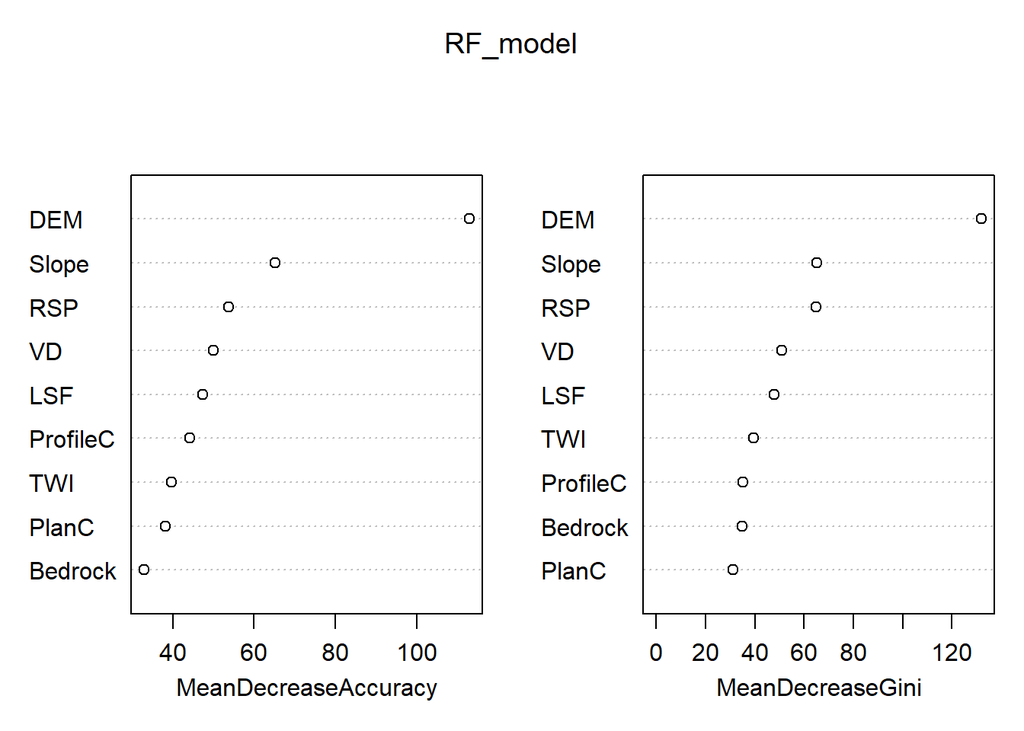

```r
sampData$soilID<-substring(as.vector(sampData$soilID),2,nchar(as.vector(sampData$soilID)))

sampData$Bedrock<-as.factor(sampData$Bedrock)
sampData$soilID<-as.factor(sampData$soilID)

RF_model<-randomForest(soilID ~.,data = sampData,
                       importance = TRUE, proximity = FALSE,ntree=1000,type="classification")

varImpPlot(RF_model)
```

```r
print(RF_model)
```

```
##
## Call:
##  randomForest(formula = soilID ~ ., data = sampData, importance = TRUE,      proximity = FALSE, ntree = 1000, type = "classification")
##                Type of random forest: classification
##                      Number of trees: 1000
## No. of variables tried at each split: 3
##
##         OOB estimate of  error rate: 17.26%
## Confusion matrix:
##     1 20 21 23  3 30 31 501 502 503  7 class.error
## 1   0  0  0  0  1  0  0   0   0   0  0  1.00000000
## 20  0 54  6  0  0  0  0   0   0  10  9  0.31645570
## 21  0 11 20  0  0  0  0   0   0   7  0  0.47368421
## 23  0  0  0 46  0  2  1   0   0   1  1  0.09803922
## 3   0  0  0  0 32  0  0   1   0   0  0  0.03030303
## 30  0  0  0 11  0  3  0   0   0   0  0  0.78571429
## 31  0  0  0  2  0  0 20   0   0   0  0  0.09090909
## 501 0  0  0  0  1  0  0 108   0   0  1  0.01818182
## 502 0  3  1  0  0  0  0   6   3   0  0  0.76923077
## 503 0  3  0  1  0  0  0   0   0 131  8  0.08391608
## 7   0  5  0  0  0  0  0   0   0  10 72  0.17241379
```

```r
map_RF <- predict(covStack, RF_model, paste(result_tif_folder,mn,".tif",sep=""),
                  format = "GTiff", datatype = "FLT4S", overwrite = TRUE)


rm("mn","shpPoint","sampData","RF_model","map_RF")
```

建模及预测—— SNA DEM ns5 25

```r
mn="All_pSNA_DEM_NS5_pen25"

shpPoint<-readOGR(paste(point_shp_folder,mn,".shp",sep = "")) ###
sampData <- extract(covStack, shpPoint, sp = TRUE,method = "simple")

sampData<-sampData@data
sampData<-na.omit(sampData)
dim(sampData)
```

```
## [1] 592  10
```

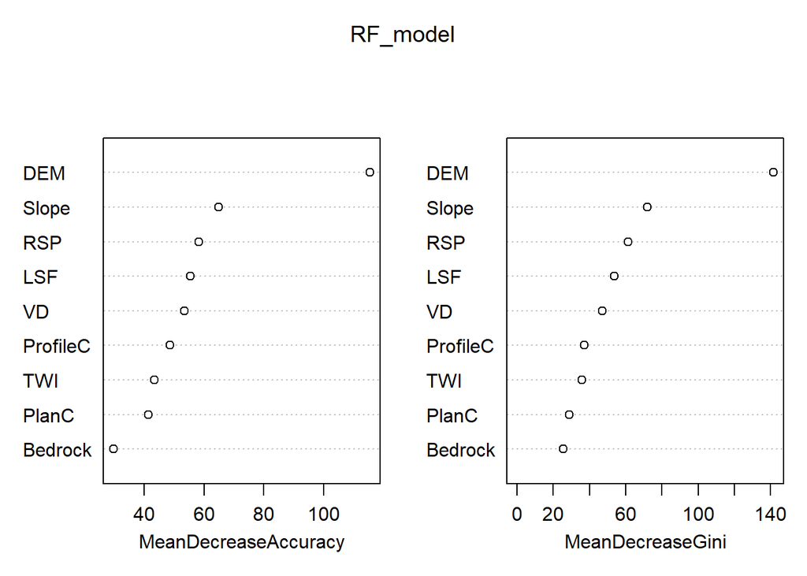

```r
sampData$soilID<-substring(as.vector(sampData$soilID),2,nchar(as.vector(sampData$soilID)))

sampData$Bedrock<-as.factor(sampData$Bedrock)
sampData$soilID<-as.factor(sampData$soilID)

RF_model<-randomForest(soilID ~.,data = sampData,
                       importance = TRUE, proximity = FALSE,ntree=1000,type="classification")

varImpPlot(RF_model)
```

```r
print(RF_model)
```

```
##
## Call:
##  randomForest(formula = soilID ~ ., data = sampData, importance = TRUE,      proximity = FALSE, ntree = 1000, type = "classification")
##                Type of random forest: classification
##                      Number of trees: 1000
## No. of variables tried at each split: 3
##
##         OOB estimate of  error rate: 18.92%
## Confusion matrix:
##     1 20 21 23  3 30 31 501 502 503  7 class.error
## 1   1  0  0  0  1  0  0   0   0   0  0  0.50000000
## 20  0 56  5  0  0  0  0   0   0   7 11  0.29113924
## 21  0 15 17  0  0  0  0   0   0   6  0  0.55263158
## 23  0  0  0 41  0  3  2   0   0   1  4  0.19607843
## 3   0  0  0  0 33  0  0   0   0   0  0  0.00000000
## 30  0  0  0 10  0  3  0   0   0   0  1  0.78571429
## 31  0  0  0  3  0  0 19   0   0   0  0  0.13636364
## 501 0  0  0  0  2  0  0 108   0   0  0  0.01818182
## 502 0  2  2  0  0  0  0   6   2   0  1  0.84615385
## 503 0  2  0  1  0  0  0   0   0 135  5  0.05594406
## 7   0  7  0  1  0  0  0   0   0  14 65  0.25287356
```

```r
map_RF <- predict(covStack, RF_model, paste(result_tif_folder,mn,".tif",sep=""),
                  format = "GTiff", datatype = "FLT4S", overwrite = TRUE)


rm("mn","shpPoint","sampData","RF_model","map_RF")
```

建模及预测—— RAN DEM 25

```r
mn="All_pRAN_DEM_pen25"

shpPoint<-readOGR(paste(point_shp_folder,mn,".shp",sep = "")) ###
sampData <- extract(covStack, shpPoint, sp = TRUE,method = "simple")

sampData<-sampData@data
sampData<-na.omit(sampData)
dim(sampData)
```

```
## [1] 593  10
```

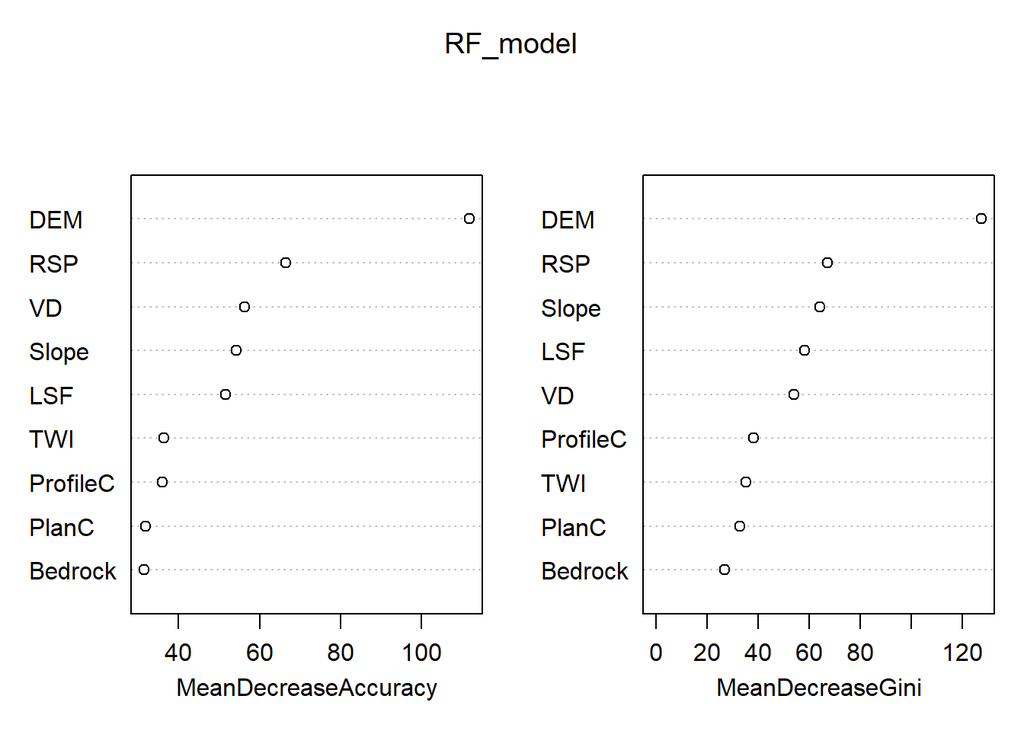

```r
sampData$soilID<-substring(as.vector(sampData$soilID),2,nchar(as.vector(sampData$soilID)))

sampData$Bedrock<-as.factor(sampData$Bedrock)
sampData$soilID<-as.factor(sampData$soilID)

RF_model<-randomForest(soilID ~.,data = sampData,
                       importance = TRUE, proximity = FALSE,ntree=1000,type="classification")

varImpPlot(RF_model)
```

```r
print(RF_model)
```

```
##
## Call:
##  randomForest(formula = soilID ~ ., data = sampData, importance = TRUE,      proximity = FALSE, ntree = 1000, type = "classification")
##                Type of random forest: classification
##                      Number of trees: 1000
## No. of variables tried at each split: 3
##
##         OOB estimate of  error rate: 28.84%
## Confusion matrix:
##     1 20 21 23  3 30 31 501 502 503  7 class.error
## 1   3  0  0  0  0  0  0   0   0   0  0  0.00000000
## 20  0 42 15  0  0  0  0   1   0  13  8  0.46835443
## 21  0 23 11  0  0  0  0   0   0   3  1  0.71052632
## 23  0  0  0 34  0  2  1   0   0  14  0  0.33333333
## 3   0  0  0  0 22  0  0  11   0   0  0  0.33333333
## 30  0  0  0  7  0  4  2   0   0   0  1  0.71428571
## 31  0  0  0  2  0  0 19   0   0   1  0  0.13636364
## 501 0  2  0  0  5  0  0 100   0   0  3  0.09090909
## 502 0  3  3  0  1  0  0   2   3   0  1  0.76923077
## 503 0  7  0  9  0  0  0   0   1 121  5  0.15384615
## 7   0  7  0  1  0  0  0   5   1  10 63  0.27586207
```

```r
map_RF <- predict(covStack, RF_model, paste(result_tif_folder,mn,".tif",sep=""),
                  format = "GTiff", datatype = "FLT4S", overwrite = TRUE)


rm("mn","shpPoint","sampData","RF_model","map_RF")
```

建模及预测—— SNA DEM ns3 75

```r
mn="All_pSNA_DEM_NS3_pen75"

shpPoint<-readOGR(paste(point_shp_folder,mn,".shp",sep = "")) ###
sampData <- extract(covStack, shpPoint, sp = TRUE,method = "simple")

sampData<-sampData@data
sampData<-na.omit(sampData)
dim(sampData)
```

```
## [1] 1647   10
```

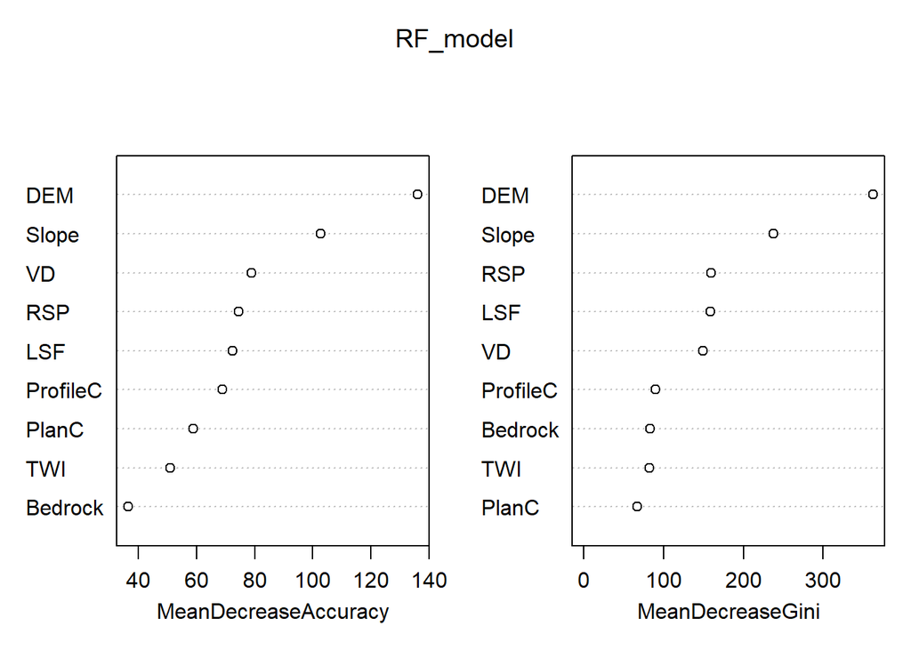

```r
sampData$soilID<-substring(as.vector(sampData$soilID),2,nchar(as.vector(sampData$soilID)))

sampData$Bedrock<-as.factor(sampData$Bedrock)
sampData$soilID<-as.factor(sampData$soilID)

RF_model<-randomForest(soilID ~.,data = sampData,
                       importance = TRUE, proximity = FALSE,ntree=1000,type="classification")

varImpPlot(RF_model)
```

```r
print(RF_model)
```

```
##
## Call:
##  randomForest(formula = soilID ~ ., data = sampData, importance = TRUE,      proximity = FALSE, ntree = 1000, type = "classification")
##                Type of random forest: classification
##                      Number of trees: 1000
## No. of variables tried at each split: 3
##
##         OOB estimate of  error rate: 13.54%
## Confusion matrix:
##     1  20 21  23  3 30 31 501 502 503   7 class.error
## 1   5   0  0   0  2  0  0   0   0   0   0  0.28571429
## 20  0 164 11   0  0  0  0   0   1  21  14  0.22274882
## 21  0  23 46   0  0  0  0   0   0   5   0  0.37837838
## 23  0   0  0 124  0  7  2   0   0   3   3  0.10791367
## 3   1   0  0   0 87  0  0  11   0   0   0  0.12121212
## 30  0   0  0  17  0 16  1   0   0   0   0  0.52941176
## 31  0   0  0   4  0  1 59   0   0   0   0  0.07812500
## 501 0   0  0   0 10  0  0 318   0   0   0  0.03048780
## 502 0   4  3   0  0  0  0   9  16   0   2  0.52941176
## 503 0  12  0   8  0  0  0   0   0 378  14  0.08252427
## 7   0  11  0   1  0  0  0   2   2  18 211  0.13877551
```

```r
map_RF <- predict(covStack, RF_model, paste(result_tif_folder,mn,".tif",sep=""),
                  format = "GTiff", datatype = "FLT4S", overwrite = TRUE)


rm("mn","shpPoint","sampData","RF_model","map_RF")
```

建模及预测—— SNA DEM ns5 75

```r
mn="All_pSNA_DEM_NS5_pen75"

shpPoint<-readOGR(paste(point_shp_folder,mn,".shp",sep = "")) ###
sampData <- extract(covStack, shpPoint, sp = TRUE,method = "simple")

sampData<-sampData@data
sampData<-na.omit(sampData)
dim(sampData)
```

```
## [1] 1648   10
```

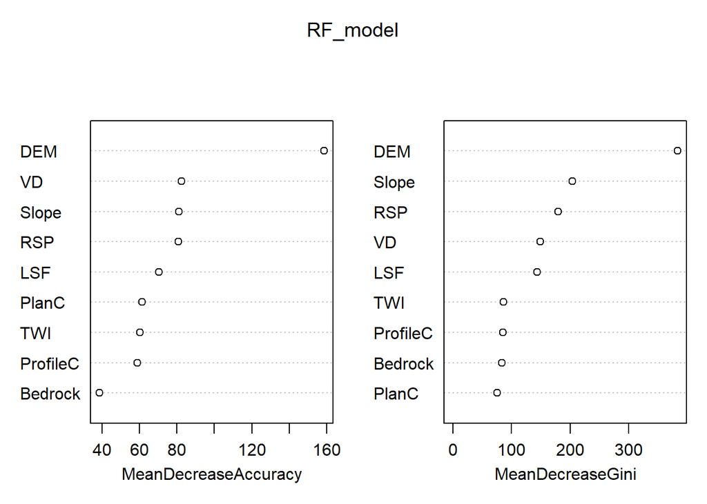

```r
sampData$soilID<-substring(as.vector(sampData$soilID),2,nchar(as.vector(sampData$soilID)))

sampData$Bedrock<-as.factor(sampData$Bedrock)
sampData$soilID<-as.factor(sampData$soilID)

RF_model<-randomForest(soilID ~.,data = sampData,
                       importance = TRUE, proximity = FALSE,ntree=1000,type="classification")

varImpPlot(RF_model)
```

```r
print(RF_model)
```

```
##
## Call:
##  randomForest(formula = soilID ~ ., data = sampData, importance = TRUE,      proximity = FALSE, ntree = 1000, type = "classification")
##                Type of random forest: classification
##                      Number of trees: 1000
## No. of variables tried at each split: 3
##
##         OOB estimate of  error rate: 16.63%
## Confusion matrix:
##     1  20 21  23  3 30 31 501 502 503   7 class.error
## 1   6   0  0   0  2  0  0   0   0   0   0  0.25000000
## 20  0 155 13   0  0  0  0   0   1  22  20  0.26540284
## 21  0  26 45   0  0  0  0   0   0   3   0  0.39189189
## 23  0   0  0 111  0  9  2   0   0   9   8  0.20143885
## 3   1   0  0   0 86  0  0  12   0   0   0  0.13131313
## 30  0   0  0  14  0 18  1   0   0   0   1  0.47058824
## 31  0   0  0   6  0  0 58   0   0   0   0  0.09375000
## 501 0   0  0   0 17  0  0 310   0   0   1  0.05487805
## 502 0   3  3   0  0  0  0   6  18   1   3  0.47058824
## 503 0  20  1  11  0  0  0   0   0 368  12  0.10679612
## 7   0  18  0   4  0  0  0   2   2  20 199  0.18775510
```

```r
map_RF <- predict(covStack, RF_model, paste(result_tif_folder,mn,".tif",sep=""),
                  format = "GTiff", datatype = "FLT4S", overwrite = TRUE)


rm("mn","shpPoint","sampData","RF_model","map_RF")
```

建模及预测—— RAN DEM 75

```r
mn="All_pRAN_DEM_pen75"

shpPoint<-readOGR(paste(point_shp_folder,mn,".shp",sep = "")) ###
sampData <- extract(covStack, shpPoint, sp = TRUE,method = "simple")

sampData<-sampData@data
sampData<-na.omit(sampData)
dim(sampData)
```

```
## [1] 1649   10
```

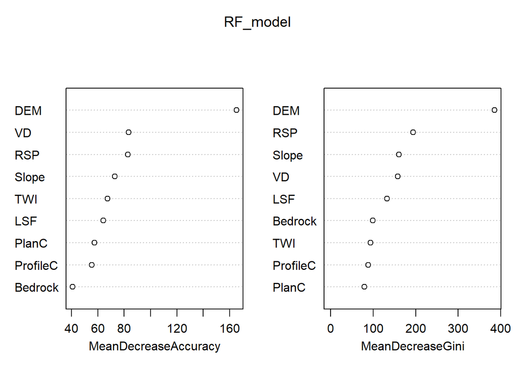

```r
sampData$soilID<-substring(as.vector(sampData$soilID),2,nchar(as.vector(sampData$soilID)))

sampData$Bedrock<-as.factor(sampData$Bedrock)
sampData$soilID<-as.factor(sampData$soilID)

RF_model<-randomForest(soilID ~.,data = sampData,
                       importance = TRUE, proximity = FALSE,ntree=1000,type="classification")

varImpPlot(RF_model)
```

```r
print(RF_model)
```

```
##
## Call:
##  randomForest(formula = soilID ~ ., data = sampData, importance = TRUE,      proximity = FALSE, ntree = 1000, type = "classification")
##                Type of random forest: classification
##                      Number of trees: 1000
## No. of variables tried at each split: 3
##
##         OOB estimate of  error rate: 18.86%
## Confusion matrix:
##     1  20 21 23  3 30 31 501 502 503   7 class.error
## 1   9   0  0  0  0  0  0   0   0   0   0  0.00000000
## 20  0 133 19  0  0  0  0   4   0  32  23  0.36966825
## 21  0  23 46  0  0  0  0   1   0   4   0  0.37837838
## 23  0   0  0 97  0  6  9   0   0  18   9  0.30215827
## 3   1   0  0  0 74  0  0  24   0   0   0  0.25252525
## 30  0   0  0  9  0 21  4   0   0   0   0  0.38235294
## 31  0   0  0  9  0  2 52   0   0   1   0  0.18750000
## 501 0   3  0  0 16  0  0 304   1   0   4  0.07317073
## 502 0   3  0  0  0  0  0   2  26   1   2  0.23529412
## 503 0  16  0 10  0  0  0   0   1 370  15  0.10194175
## 7   0  15  0  3  0  1  0  10   1   9 206  0.15918367
```

```r
map_RF <- predict(covStack, RF_model, paste(result_tif_folder,mn,".tif",sep=""),
                  format = "GTiff", datatype = "FLT4S", overwrite = TRUE)


rm("mn","shpPoint","sampData","RF_model","map_RF")
```

# Slope

建模及预测—— SNA Slope ns3 25

```r
mn="All_pSNA_Slope_NS3_pen25"

shpPoint<-readOGR(paste(point_shp_folder,mn,".shp",sep = "")) ###
sampData <- extract(covStack, shpPoint, sp = TRUE,method = "simple")

sampData<-sampData@data
sampData<-na.omit(sampData)
dim(sampData)
```

```
## [1] 549  10
```

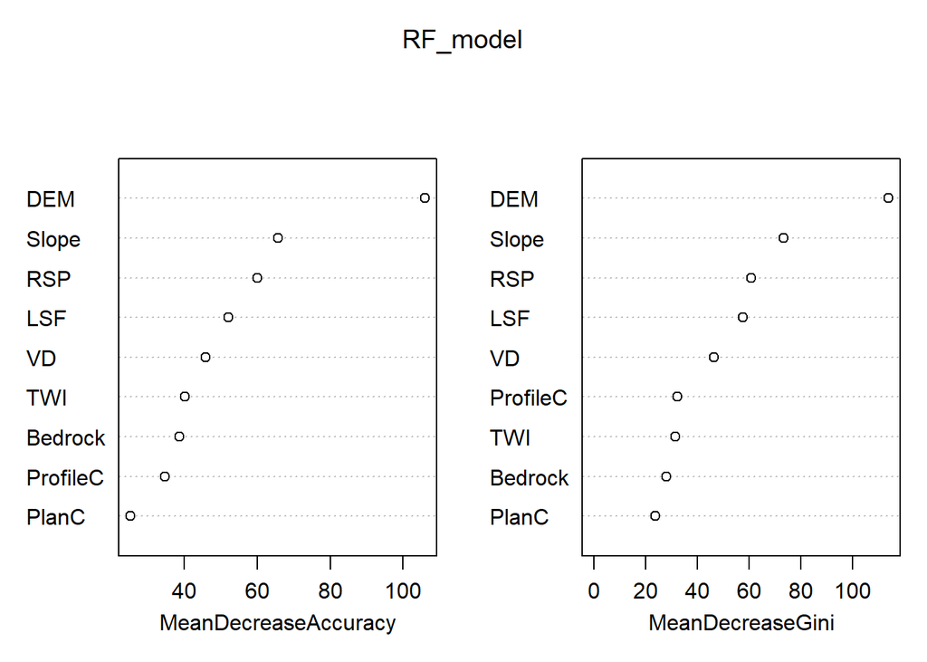

```r
sampData$soilID<-substring(as.vector(sampData$soilID),2,nchar(as.vector(sampData$soilID)))

sampData$Bedrock<-as.factor(sampData$Bedrock)
sampData$soilID<-as.factor(sampData$soilID)

RF_model<-randomForest(soilID ~.,data = sampData,
                       importance = TRUE, proximity = FALSE,ntree=1000,type="classification")

varImpPlot(RF_model)
```

```r
print(RF_model)
```

```
##
## Call:
##  randomForest(formula = soilID ~ ., data = sampData, importance = TRUE,      proximity = FALSE, ntree = 1000, type = "classification")
##                Type of random forest: classification
##                      Number of trees: 1000
## No. of variables tried at each split: 3
##
##         OOB estimate of  error rate: 24.77%
## Confusion matrix:
##     1 20 21 23  3 30 31 501 502 503  7 class.error
## 1   0  0  0  0  2  0  0   0   0   0  0  1.00000000
## 20  0 39  6  0  0  0  0   2   2  12 15  0.48684211
## 21  0 13 19  0  0  0  0   0   0   4  0  0.47222222
## 23  0  0  0 32  0  1  4   0   0   7  1  0.28888889
## 3   1  0  0  0 24  0  0   6   0   0  0  0.22580645
## 30  0  1  0  5  0  7  1   0   0   0  0  0.50000000
## 31  0  0  0  5  0  0 16   0   0   0  0  0.23809524
## 501 0  1  0  0  6  0  0  93   0   0  1  0.07920792
## 502 0  2  0  0  0  0  0   0   7   1  2  0.41666667
## 503 0  7  1  1  0  0  0   0   0 117  4  0.10000000
## 7   0 10  0  0  0  2  0   4   1   5 59  0.27160494
```

```r
map_RF <- predict(covStack, RF_model, paste(result_tif_folder,mn,".tif",sep=""),
                  format = "GTiff", datatype = "FLT4S", overwrite = TRUE)


rm("mn","shpPoint","sampData","RF_model","map_RF")
```

建模及预测—— SNA Slope ns5 25

```r
mn="All_pSNA_Slope_NS5_pen25"

shpPoint<-readOGR(paste(point_shp_folder,mn,".shp",sep = "")) ###
sampData <- extract(covStack, shpPoint, sp = TRUE,method = "simple")

sampData<-sampData@data
sampData<-na.omit(sampData)
dim(sampData)
```

```
## [1] 551  10
```

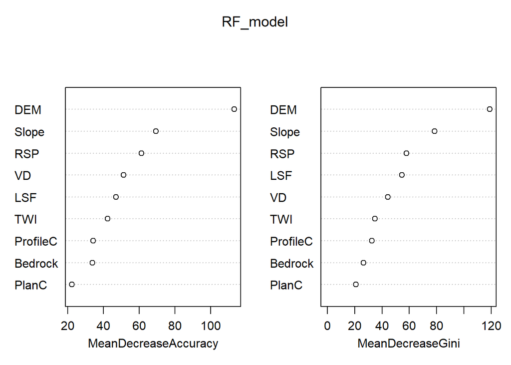

```r
sampData$soilID<-substring(as.vector(sampData$soilID),2,nchar(as.vector(sampData$soilID)))

sampData$Bedrock<-as.factor(sampData$Bedrock)
sampData$soilID<-as.factor(sampData$soilID)

RF_model<-randomForest(soilID ~.,data = sampData,
                       importance = TRUE, proximity = FALSE,ntree=1000,type="classification")

varImpPlot(RF_model)
```

```r
print(RF_model)
```

```
##
## Call:
##  randomForest(formula = soilID ~ ., data = sampData, importance = TRUE,      proximity = FALSE, ntree = 1000, type = "classification")
##                Type of random forest: classification
##                      Number of trees: 1000
## No. of variables tried at each split: 3
##
##         OOB estimate of  error rate: 21.78%
## Confusion matrix:
##     1 20 21 23  3 30 31 501 502 503  7 class.error
## 1   3  0  0  0  1  0  0   0   0   0  0  0.25000000
## 20  0 42  7  0  0  0  0   2   0  14 11  0.44736842
## 21  0 11 22  0  0  0  0   1   0   2  0  0.38888889
## 23  0  0  0 32  0  2  1   0   0   8  2  0.28888889
## 3   0  0  0  0 24  0  0   7   0   0  0  0.22580645
## 30  0  0  0  2  0 10  2   0   0   0  0  0.28571429
## 31  0  0  0  0  0  0 21   0   0   0  0  0.00000000
## 501 0  1  0  0  5  0  0  93   0   0  2  0.07920792
## 502 0  3  0  0  0  0  0   0   7   1  1  0.41666667
## 503 0 10  0  2  0  0  0   0   0 115  3  0.11538462
## 7   0 10  0  0  0  1  0   4   0   4 62  0.23456790
```

```r
map_RF <- predict(covStack, RF_model, paste(result_tif_folder,mn,".tif",sep=""),
                  format = "GTiff", datatype = "FLT4S", overwrite = TRUE)


rm("mn","shpPoint","sampData","RF_model","map_RF")
```

建模及预测—— RAN Slope 25

```r
mn="All_pRAN_Slope_pen25"

shpPoint<-readOGR(paste(point_shp_folder,mn,".shp",sep = "")) ###
sampData <- extract(covStack, shpPoint, sp = TRUE,method = "simple")

sampData<-sampData@data
sampData<-na.omit(sampData)
dim(sampData)
```

```
## [1] 551  10
```

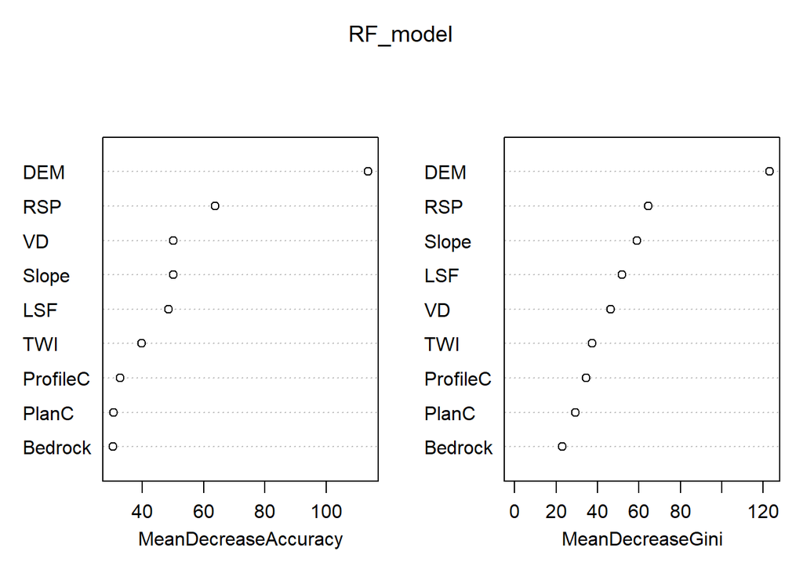

```r
sampData$soilID<-substring(as.vector(sampData$soilID),2,nchar(as.vector(sampData$soilID)))

sampData$Bedrock<-as.factor(sampData$Bedrock)
sampData$soilID<-as.factor(sampData$soilID)

RF_model<-randomForest(soilID ~.,data = sampData,
                       importance = TRUE, proximity = FALSE,ntree=1000,type="classification")

varImpPlot(RF_model)
```

```r
print(RF_model)
```

```
##
## Call:
##  randomForest(formula = soilID ~ ., data = sampData, importance = TRUE,      proximity = FALSE, ntree = 1000, type = "classification")
##                Type of random forest: classification
##                      Number of trees: 1000
## No. of variables tried at each split: 3
##
##         OOB estimate of  error rate: 27.04%
## Confusion matrix:
##     1 20 21 23  3 30 31 501 502 503  7 class.error
## 1   3  0  0  0  1  0  0   0   0   0  0  0.25000000
## 20  0 36 11  0  0  0  0   3   1  17  8  0.52631579
## 21  0 19 14  0  0  0  0   0   0   2  1  0.61111111
## 23  0  0  0 29  0  3  2   0   0  10  1  0.35555556
## 3   0  0  0  0 25  0  0   6   0   0  0  0.19354839
## 30  0  0  0  8  0  2  2   0   0   1  1  0.85714286
## 31  0  0  0  3  0  1 17   0   0   0  0  0.19047619
## 501 0  1  0  0  4  0  0  93   1   0  2  0.07920792
## 502 0  4  1  0  0  0  0   2   4   0  1  0.66666667
## 503 0  6  1  4  0  0  0   0   0 115  4  0.11538462
## 7   0  8  0  0  0  0  0   3   1   5 64  0.20987654
```

```r
map_RF <- predict(covStack, RF_model, paste(result_tif_folder,mn,".tif",sep=""),
                  format = "GTiff", datatype = "FLT4S", overwrite = TRUE)


rm("mn","shpPoint","sampData","RF_model","map_RF")
```

建模及预测—— SNA Slope ns3 75

```r
mn="All_pSNA_Slope_NS3_pen75"

shpPoint<-readOGR(paste(point_shp_folder,mn,".shp",sep = "")) ###
sampData <- extract(covStack, shpPoint, sp = TRUE,method = "simple")

sampData<-sampData@data
sampData<-na.omit(sampData)
dim(sampData)
```

```
## [1] 1536   10
```

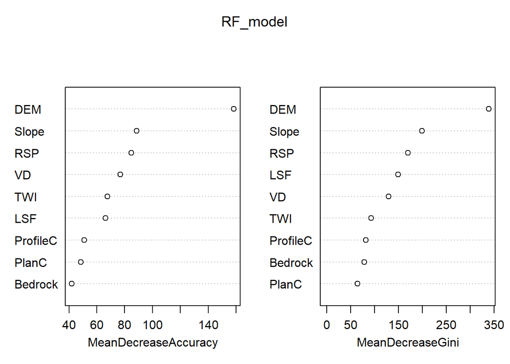

```r
sampData$soilID<-substring(as.vector(sampData$soilID),2,nchar(as.vector(sampData$soilID)))

sampData$Bedrock<-as.factor(sampData$Bedrock)
sampData$soilID<-as.factor(sampData$soilID)

RF_model<-randomForest(soilID ~.,data = sampData,
                       importance = TRUE, proximity = FALSE,ntree=1000,type="classification")

varImpPlot(RF_model)
```

```r
print(RF_model)
```

```
##
## Call:
##  randomForest(formula = soilID ~ ., data = sampData, importance = TRUE,      proximity = FALSE, ntree = 1000, type = "classification")
##                Type of random forest: classification
##                      Number of trees: 1000
## No. of variables tried at each split: 3
##
##         OOB estimate of  error rate: 17.77%
## Confusion matrix:
##     1  20 21  23  3 30 31 501 502 503   7 class.error
## 1   5   0  0   0  3  0  0   0   0   0   0  0.37500000
## 20  0 132 10   0  0  0  0   5   1  28  24  0.34000000
## 21  0  22 46   0  0  0  0   1   2   5   0  0.39473684
## 23  0   0  0 105  0  7  5   0   0  13   2  0.20454545
## 3   2   0  0   0 71  0  0  18   0   0   0  0.21978022
## 30  0   0  1   6  0 29  1   0   0   0   0  0.21621622
## 31  0   0  0   3  0  0 59   0   0   0   0  0.04838710
## 501 0   0  0   0 11  0  0 278   0   1  11  0.07641196
## 502 0   4  1   0  0  0  0   1  22   1   3  0.31250000
## 503 0  17  1  10  0  0  0   0   1 334   7  0.09729730
## 7   0  18  0   2  0  2  0  12   1  10 182  0.19823789
```

```r
map_RF <- predict(covStack, RF_model, paste(result_tif_folder,mn,".tif",sep=""),
                  format = "GTiff", datatype = "FLT4S", overwrite = TRUE)


rm("mn","shpPoint","sampData","RF_model","map_RF")
```

建模及预测—— SNA Slope ns5 75

```r
mn="All_pSNA_Slope_NS5_pen75"

shpPoint<-readOGR(paste(point_shp_folder,mn,".shp",sep = "")) ###
sampData <- extract(covStack, shpPoint, sp = TRUE,method = "simple")

sampData<-sampData@data
sampData<-na.omit(sampData)
dim(sampData)
```

```
## [1] 1536   10
```

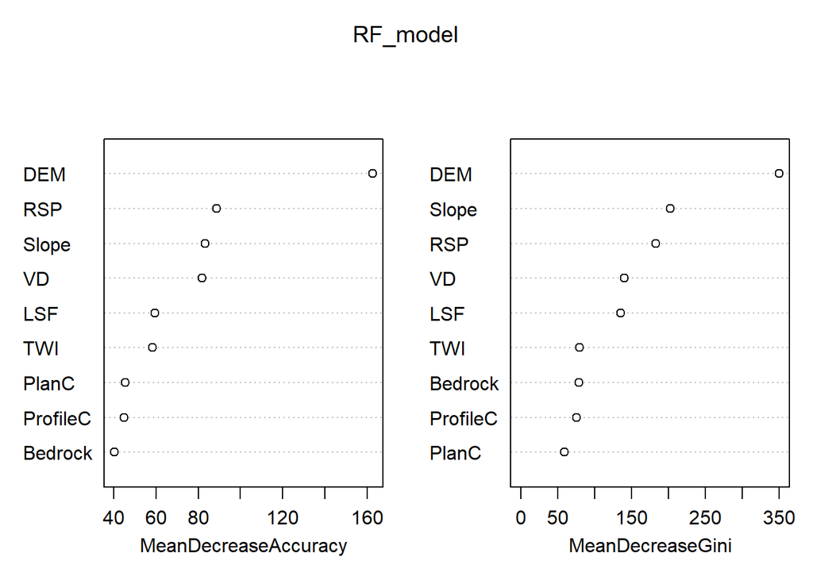

```r
sampData$soilID<-substring(as.vector(sampData$soilID),2,nchar(as.vector(sampData$soilID)))

sampData$Bedrock<-as.factor(sampData$Bedrock)
sampData$soilID<-as.factor(sampData$soilID)

RF_model<-randomForest(soilID ~.,data = sampData,
                       importance = TRUE, proximity = FALSE,ntree=1000,type="classification")

varImpPlot(RF_model)
```

```r
print(RF_model)
```

```
##
## Call:
##  randomForest(formula = soilID ~ ., data = sampData, importance = TRUE,      proximity = FALSE, ntree = 1000, type = "classification")
##                Type of random forest: classification
##                      Number of trees: 1000
## No. of variables tried at each split: 3
##
##         OOB estimate of  error rate: 18.1%
## Confusion matrix:
##     1  20 21  23  3 30 31 501 502 503   7 class.error
## 1   6   0  0   0  2  0  0   0   0   0   0  0.25000000
## 20  0 129 15   0  0  0  0   4   0  27  25  0.35500000
## 21  0  26 45   0  0  0  0   1   1   3   0  0.40789474
## 23  0   0  0 101  0  9  2   0   0  15   5  0.23484848
## 3   0   0  0   0 76  0  0  15   0   0   0  0.16483516
## 30  0   0  0   8  0 27  1   0   0   0   1  0.27027027
## 31  0   0  0   0  0  1 60   0   0   1   0  0.03225806
## 501 0   1  0   0 14  0  0 281   0   0   5  0.06644518
## 502 0   4  0   0  0  0  0   0  26   0   2  0.18750000
## 503 0  20  2  10  0  0  0   0   0 328  10  0.11351351
## 7   0  24  0   1  0  2  0   8   0  13 179  0.21145374
```

```r
map_RF <- predict(covStack, RF_model, paste(result_tif_folder,mn,".tif",sep=""),
                  format = "GTiff", datatype = "FLT4S", overwrite = TRUE)


rm("mn","shpPoint","sampData","RF_model","map_RF")
```

建模及预测—— RAN Slope 75

```r
mn="All_pRAN_Slope_pen75"

shpPoint<-readOGR(paste(point_shp_folder,mn,".shp",sep = "")) ###
sampData <- extract(covStack, shpPoint, sp = TRUE,method = "simple")

sampData<-sampData@data
sampData<-na.omit(sampData)
dim(sampData)
```

```
## [1] 1538   10
```

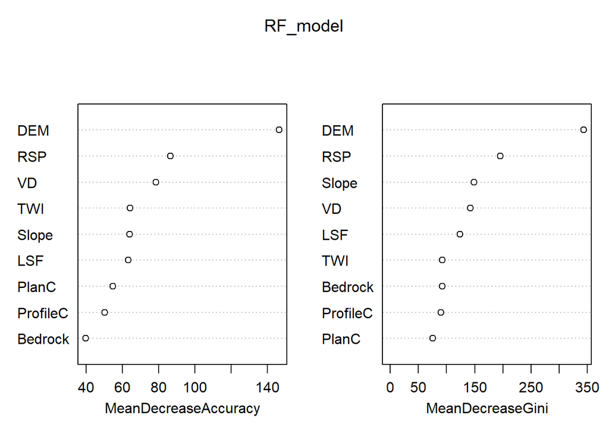

```r
sampData$soilID<-substring(as.vector(sampData$soilID),2,nchar(as.vector(sampData$soilID)))

sampData$Bedrock<-as.factor(sampData$Bedrock)
sampData$soilID<-as.factor(sampData$soilID)

RF_model<-randomForest(soilID ~.,data = sampData,
                       importance = TRUE, proximity = FALSE,ntree=1000,type="classification")

varImpPlot(RF_model)
```

```r
print(RF_model)
```

```
##
## Call:
##  randomForest(formula = soilID ~ ., data = sampData, importance = TRUE,      proximity = FALSE, ntree = 1000, type = "classification")
##                Type of random forest: classification
##                      Number of trees: 1000
## No. of variables tried at each split: 3
##
##         OOB estimate of  error rate: 22.69%
## Confusion matrix:
##     1  20 21 23  3 30 31 501 502 503   7 class.error
## 1   8   0  0  0  2  0  0   0   0   0   0  0.20000000
## 20  0 119 14  0  0  0  0   4   4  33  26  0.40500000
## 21  0  36 32  0  0  0  0   1   1   6   0  0.57894737
## 23  0   0  0 97  0  9  5   0   0  15   6  0.26515152
## 3   1   0  0  0 62  0  0  28   0   0   0  0.31868132
## 30  0   0  0 13  0 21  3   0   0   0   0  0.43243243
## 31  0   0  0 10  0  4 48   0   0   0   0  0.22580645
## 501 0   0  0  0 16  0  0 277   0   0   8  0.07973422
## 502 0   2  2  0  0  0  0   3  22   1   2  0.31250000
## 503 0  24  3 11  0  1  0   0   1 319  11  0.13783784
## 7   0  18  0  1  0  1  0  10   1  12 184  0.18942731
```

```r
map_RF <- predict(covStack, RF_model, paste(result_tif_folder,mn,".tif",sep=""),
                  format = "GTiff", datatype = "FLT4S", overwrite = TRUE)


rm("mn","shpPoint","sampData","RF_model","map_RF")
```

# PlanC

建模及预测—— SNA PlanC ns3 25

```r
mn="All_pSNA_PlanC_NS3_pen25"

shpPoint<-readOGR(paste(point_shp_folder,mn,".shp",sep = "")) ###
sampData <- extract(covStack, shpPoint, sp = TRUE,method = "simple")

sampData<-sampData@data
sampData<-na.omit(sampData)
dim(sampData)
```

```
## [1] 569  10
```

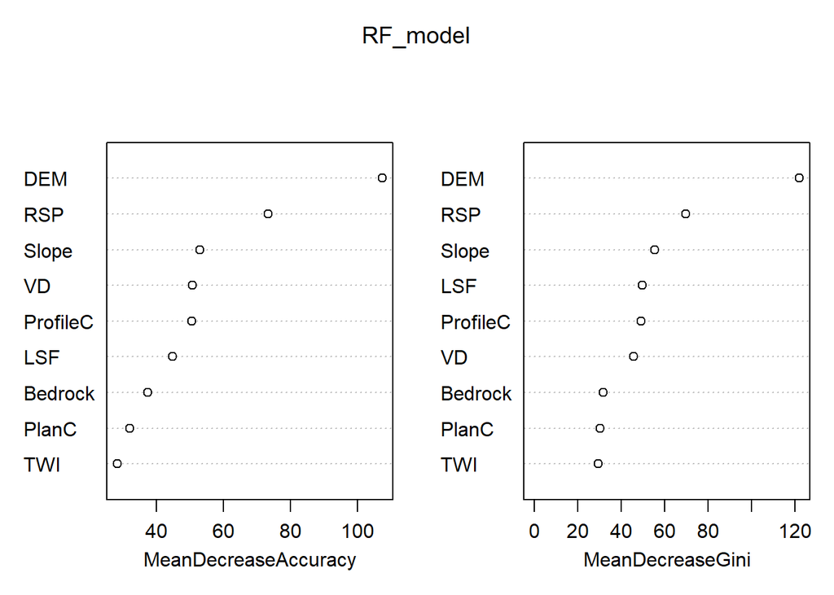

```r
sampData$soilID<-substring(as.vector(sampData$soilID),2,nchar(as.vector(sampData$soilID)))

sampData$Bedrock<-as.factor(sampData$Bedrock)
sampData$soilID<-as.factor(sampData$soilID)

RF_model<-randomForest(soilID ~.,data = sampData,
                       importance = TRUE, proximity = FALSE,ntree=1000,type="classification")

varImpPlot(RF_model)
```

```r
print(RF_model)
```

```
##
## Call:
##  randomForest(formula = soilID ~ ., data = sampData, importance = TRUE,      proximity = FALSE, ntree = 1000, type = "classification")
##                Type of random forest: classification
##                      Number of trees: 1000
## No. of variables tried at each split: 3
##
##         OOB estimate of  error rate: 24.78%
## Confusion matrix:
##     1 20 21 23  3 30 31 501 502 503  7 class.error
## 1   1  0  0  0  2  0  0   0   0   0  0  0.66666667
## 20  0 32 13  0  0  0  0   1   0  20 11  0.58441558
## 21  0 14 17  0  0  0  0   0   0   3  1  0.51428571
## 23  0  0  0 42  0  2  1   0   0   2  1  0.12500000
## 3   1  0  0  0 24  0  0   5   0   0  0  0.20000000
## 30  0  0  0  6  0  7  0   0   0   0  1  0.50000000
## 31  0  0  0  2  0  0 21   0   0   0  0  0.08695652
## 501 0  1  0  0  7  0  0  96   0   0  2  0.09433962
## 502 0  1  0  0  0  0  0   1   5   2  3  0.58333333
## 503 0 12  3  4  0  0  0   0   0 111  4  0.17164179
## 7   0  6  0  1  0  0  0   4   0   4 72  0.17241379
```

```r
map_RF <- predict(covStack, RF_model, paste(result_tif_folder,mn,".tif",sep=""),
                  format = "GTiff", datatype = "FLT4S", overwrite = TRUE)


rm("mn","shpPoint","sampData","RF_model","map_RF")
```

建模及预测—— SNA PlanC ns5 25

```r
mn="All_pSNA_PlanC_NS5_pen25"

shpPoint<-readOGR(paste(point_shp_folder,mn,".shp",sep = "")) ###
sampData <- extract(covStack, shpPoint, sp = TRUE,method = "simple")

sampData<-sampData@data
sampData<-na.omit(sampData)
dim(sampData)
```

```
## [1] 569  10
```

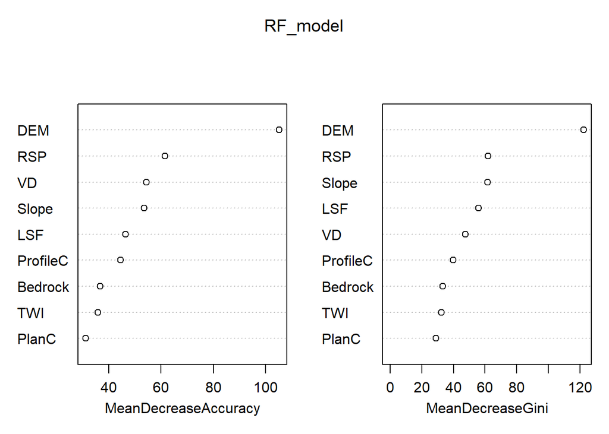

```r
sampData$soilID<-substring(as.vector(sampData$soilID),2,nchar(as.vector(sampData$soilID)))

sampData$Bedrock<-as.factor(sampData$Bedrock)
sampData$soilID<-as.factor(sampData$soilID)

RF_model<-randomForest(soilID ~.,data = sampData,
                       importance = TRUE, proximity = FALSE,ntree=1000,type="classification")

varImpPlot(RF_model)
```

```r
print(RF_model)
```

```
##
## Call:
##  randomForest(formula = soilID ~ ., data = sampData, importance = TRUE,      proximity = FALSE, ntree = 1000, type = "classification")
##                Type of random forest: classification
##                      Number of trees: 1000
## No. of variables tried at each split: 3
##
##         OOB estimate of  error rate: 24.25%
## Confusion matrix:
##     1 20 21 23  3 30 31 501 502 503  7 class.error
## 1   2  0  0  0  1  0  0   0   0   0  0   0.3333333
## 20  0 41  9  0  0  0  0   0   0  14 13   0.4675325
## 21  0 12 18  0  0  0  0   0   0   5  0   0.4857143
## 23  0  0  0 34  0  5  4   0   0   5  0   0.2916667
## 3   1  0  0  0 23  0  0   6   0   0  0   0.2333333
## 30  0  0  0  4  0  9  1   0   0   0  0   0.3571429
## 31  0  0  0  2  0  1 20   0   0   0  0   0.1304348
## 501 0  0  0  0  9  0  0  95   0   0  2   0.1037736
## 502 0  2  0  0  0  0  0   2   5   1  2   0.5833333
## 503 0  9  3  4  0  0  0   0   0 113  5   0.1567164
## 7   0  8  0  0  0  1  0   2   1   4 71   0.1839080
```

```r
map_RF <- predict(covStack, RF_model, paste(result_tif_folder,mn,".tif",sep=""),
                  format = "GTiff", datatype = "FLT4S", overwrite = TRUE)


rm("mn","shpPoint","sampData","RF_model","map_RF")
```

建模及预测—— RAN PlanC 25

```r
mn="All_pRAN_PlanC_pen25"

shpPoint<-readOGR(paste(point_shp_folder,mn,".shp",sep = "")) ###
sampData <- extract(covStack, shpPoint, sp = TRUE,method = "simple")

sampData<-sampData@data
sampData<-na.omit(sampData)
dim(sampData)
```

```
## [1] 569  10
```

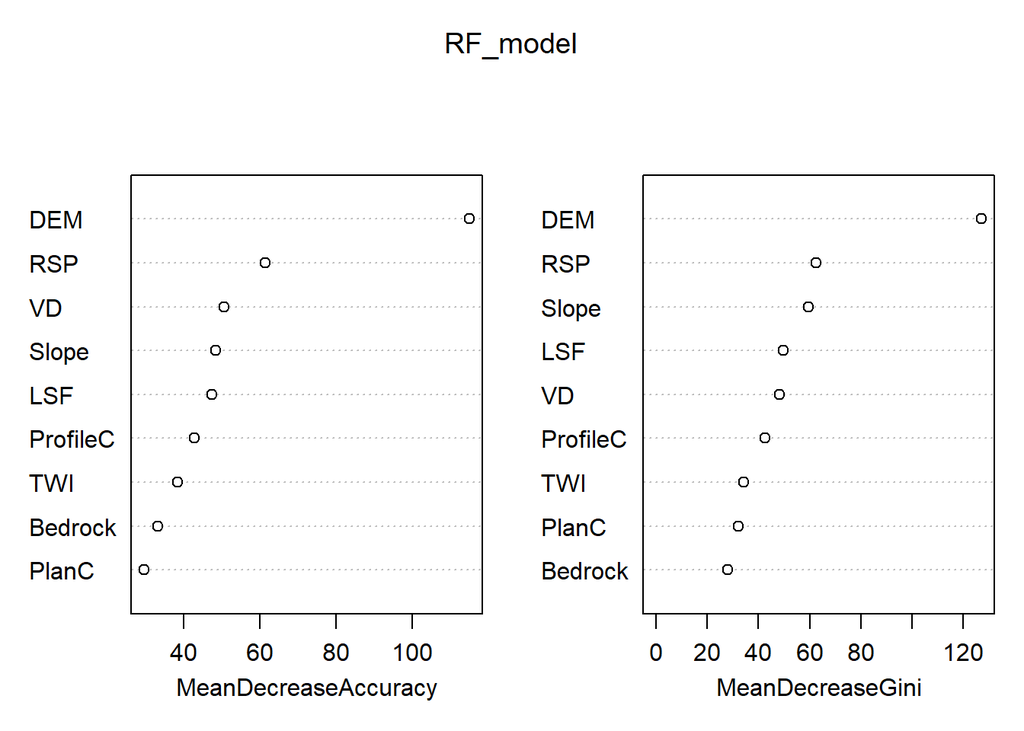

```r
sampData$soilID<-substring(as.vector(sampData$soilID),2,nchar(as.vector(sampData$soilID)))

sampData$Bedrock<-as.factor(sampData$Bedrock)
sampData$soilID<-as.factor(sampData$soilID)

RF_model<-randomForest(soilID ~.,data = sampData,
                       importance = TRUE, proximity = FALSE,ntree=1000,type="classification")

varImpPlot(RF_model)
```

```r
print(RF_model)
```

```
##
## Call:
##  randomForest(formula = soilID ~ ., data = sampData, importance = TRUE,      proximity = FALSE, ntree = 1000, type = "classification")
##                Type of random forest: classification
##                      Number of trees: 1000
## No. of variables tried at each split: 3
##
##         OOB estimate of  error rate: 28.65%
## Confusion matrix:
##     1 20 21 23  3 30 31 501 502 503  7 class.error
## 1   2  0  0  0  1  0  0   0   0   0  0   0.3333333
## 20  0 40 11  0  0  0  0   0   1  18  7   0.4805195
## 21  0 14 18  0  0  0  0   0   0   2  1   0.4857143
## 23  0  0  0 31  0  6  0   0   0   8  3   0.3541667
## 3   0  0  0  0 21  0  0   9   0   0  0   0.3000000
## 30  0  0  0  9  0  3  1   0   0   0  1   0.7857143
## 31  0  0  0  2  0  2 18   0   0   1  0   0.2173913
## 501 0  0  0  0  5  0  0  98   0   0  3   0.0754717
## 502 0  1  1  0  0  0  0   5   3   1  1   0.7500000
## 503 0 15  1  7  0  0  0   0   1 107  3   0.2014925
## 7   0  7  0  2  0  0  0   6   1   6 65   0.2528736
```

```r
map_RF <- predict(covStack, RF_model, paste(result_tif_folder,mn,".tif",sep=""),
                  format = "GTiff", datatype = "FLT4S", overwrite = TRUE)


rm("mn","shpPoint","sampData","RF_model","map_RF")
```

建模及预测—— SNA PlanC ns3 75

```r
mn="All_pSNA_PlanC_NS3_pen75"

shpPoint<-readOGR(paste(point_shp_folder,mn,".shp",sep = "")) ###
sampData <- extract(covStack, shpPoint, sp = TRUE,method = "simple")

sampData<-sampData@data
sampData<-na.omit(sampData)
dim(sampData)
```

```
## [1] 1578   10
```

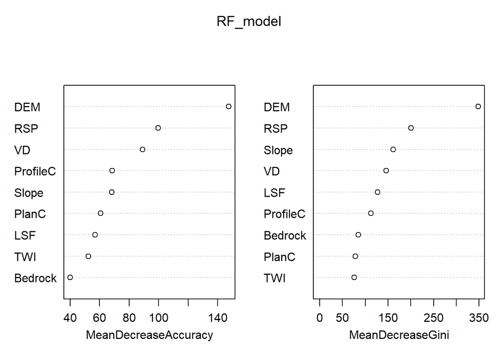

```r
sampData$soilID<-substring(as.vector(sampData$soilID),2,nchar(as.vector(sampData$soilID)))

sampData$Bedrock<-as.factor(sampData$Bedrock)
sampData$soilID<-as.factor(sampData$soilID)

RF_model<-randomForest(soilID ~.,data = sampData,
                       importance = TRUE, proximity = FALSE,ntree=1000,type="classification")

varImpPlot(RF_model)
```

```r
print(RF_model)
```

```
##
## Call:
##  randomForest(formula = soilID ~ ., data = sampData, importance = TRUE,      proximity = FALSE, ntree = 1000, type = "classification")
##                Type of random forest: classification
##                      Number of trees: 1000
## No. of variables tried at each split: 3
##
##         OOB estimate of  error rate: 17.43%
## Confusion matrix:
##     1  20 21  23  3 30 31 501 502 503   7 class.error
## 1   4   0  0   0  3  0  0   0   0   0   0  0.42857143
## 20  0 116 17   0  0  0  0   1   2  40  24  0.42000000
## 21  0  27 38   0  0  0  0   0   0   7   1  0.47945205
## 23  0   0  0 117  0  4  1   0   0  12   0  0.12686567
## 3   1   0  0   0 72  0  0  17   0   0   0  0.20000000
## 30  0   0  0   5  0 26  0   0   0   1   2  0.23529412
## 31  0   0  0   4  0  1 62   0   0   0   0  0.07462687
## 501 0   1  0   0  8  0  0 298   1   0   7  0.05396825
## 502 0   2  0   0  0  0  0   1  23   2   5  0.30303030
## 503 0  26  2   7  0  1  0   0   0 341   6  0.10966057
## 7   0  16  0   0  0  1  0   9   1   9 206  0.14876033
```

```r
map_RF <- predict(covStack, RF_model, paste(result_tif_folder,mn,".tif",sep=""),
                  format = "GTiff", datatype = "FLT4S", overwrite = TRUE)


rm("mn","shpPoint","sampData","RF_model","map_RF")
```

建模及预测—— SNA PlanC ns5 75

```r
mn="All_pSNA_PlanC_NS5_pen75"

shpPoint<-readOGR(paste(point_shp_folder,mn,".shp",sep = "")) ###
sampData <- extract(covStack, shpPoint, sp = TRUE,method = "simple")

sampData<-sampData@data
sampData<-na.omit(sampData)
dim(sampData)
```

```
## [1] 1577   10
```

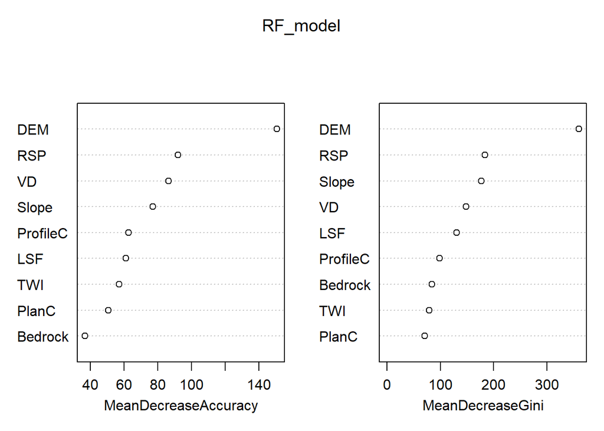

```r
sampData$soilID<-substring(as.vector(sampData$soilID),2,nchar(as.vector(sampData$soilID)))

sampData$Bedrock<-as.factor(sampData$Bedrock)
sampData$soilID<-as.factor(sampData$soilID)

RF_model<-randomForest(soilID ~.,data = sampData,
                       importance = TRUE, proximity = FALSE,ntree=1000,type="classification")

varImpPlot(RF_model)
```

```r
print(RF_model)
```

```
##
## Call:
##  randomForest(formula = soilID ~ ., data = sampData, importance = TRUE,      proximity = FALSE, ntree = 1000, type = "classification")
##                Type of random forest: classification
##                      Number of trees: 1000
## No. of variables tried at each split: 3
##
##         OOB estimate of  error rate: 18.83%
## Confusion matrix:
##     1  20 21  23  3 30 31 501 502 503   7 class.error
## 1   3   0  0   0  3  0  0   0   0   0   0  0.50000000
## 20  0 133 13   0  0  0  0   0   0  27  27  0.33500000
## 21  0  22 45   0  0  0  0   0   1   5   0  0.38356164
## 23  0   0  0 100  0  9  5   0   0  18   2  0.25373134
## 3   1   0  0   0 67  0  0  22   0   0   0  0.25555556
## 30  0   0  0   6  0 24  1   0   0   0   3  0.29411765
## 31  0   0  0   7  0  1 59   0   0   0   0  0.11940299
## 501 0   0  0   0 17  0  0 291   1   0   6  0.07619048
## 502 0   4  1   0  0  0  0   2  22   1   3  0.33333333
## 503 0  17  3  12  0  0  0   0   0 337  14  0.12010444
## 7   0  14  0   2  0  3  0  10   0  14 199  0.17768595
```

```r
map_RF <- predict(covStack, RF_model, paste(result_tif_folder,mn,".tif",sep=""),
                  format = "GTiff", datatype = "FLT4S", overwrite = TRUE)


rm("mn","shpPoint","sampData","RF_model","map_RF")
```

建模及预测—— RAN PlanC 75

```r
mn="All_pRAN_PlanC_pen75"

shpPoint<-readOGR(paste(point_shp_folder,mn,".shp",sep = "")) ###
sampData <- extract(covStack, shpPoint, sp = TRUE,method = "simple")

sampData<-sampData@data
sampData<-na.omit(sampData)
dim(sampData)
```

```
## [1] 1578   10
```

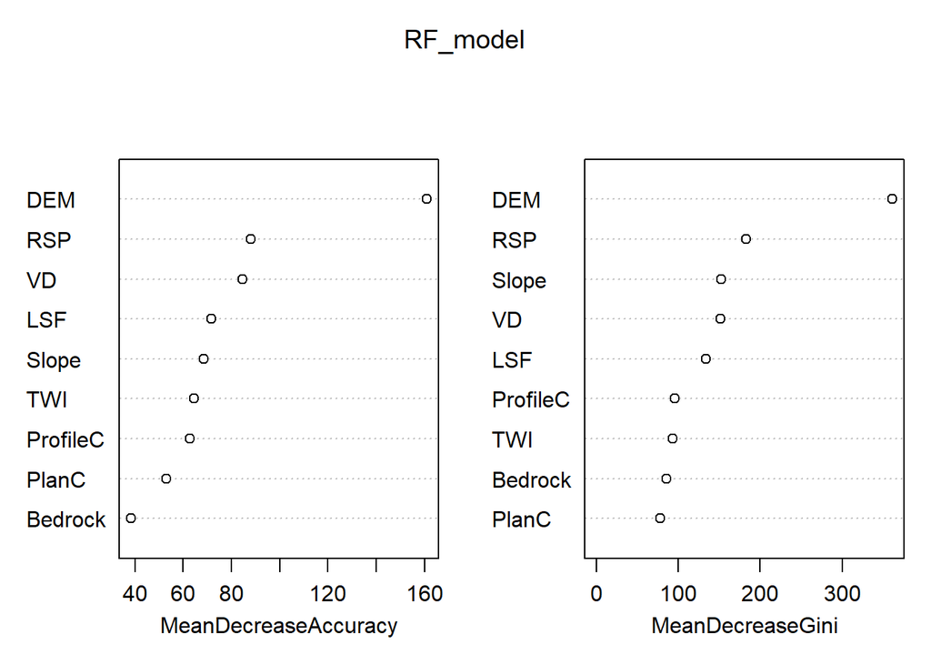

```r
sampData$soilID<-substring(as.vector(sampData$soilID),2,nchar(as.vector(sampData$soilID)))

sampData$Bedrock<-as.factor(sampData$Bedrock)
sampData$soilID<-as.factor(sampData$soilID)

RF_model<-randomForest(soilID ~.,data = sampData,
                       importance = TRUE, proximity = FALSE,ntree=1000,type="classification")

varImpPlot(RF_model)
```

```r
print(RF_model)
```

```
##
## Call:
##  randomForest(formula = soilID ~ ., data = sampData, importance = TRUE,      proximity = FALSE, ntree = 1000, type = "classification")
##                Type of random forest: classification
##                      Number of trees: 1000
## No. of variables tried at each split: 3
##
##         OOB estimate of  error rate: 20.22%
## Confusion matrix:
##     1  20 21 23  3 30 31 501 502 503   7 class.error
## 1   5   0  0  0  2  0  0   0   0   0   0  0.28571429
## 20  0 127 20  0  0  0  0   2   1  33  17  0.36500000
## 21  0  32 35  0  0  0  0   0   0   6   0  0.52054795
## 23  0   0  0 99  0  6  5   0   0  16   8  0.26119403
## 3   2   0  0  0 61  0  0  27   0   0   0  0.32222222
## 30  0   0  0  8  0 22  4   0   0   0   0  0.35294118
## 31  0   0  0  7  0  2 58   0   0   0   0  0.13432836
## 501 0   1  0  0 15  0  0 286   2   0  11  0.09206349
## 502 0   3  1  0  0  0  0   2  25   1   1  0.24242424
## 503 0  23  1 12  0  0  0   0   0 341   6  0.10966057
## 7   0  14  1  2  0  0  0  14   0  11 200  0.17355372
```

```r
map_RF <- predict(covStack, RF_model, paste(result_tif_folder,mn,".tif",sep=""),
                  format = "GTiff", datatype = "FLT4S", overwrite = TRUE)


rm("mn","shpPoint","sampData","RF_model","map_RF")
```

# TWI

建模及预测—— SNA TWI ns3 25

```r
mn="All_pSNA_TWI_NS3_pen25"

shpPoint<-readOGR(paste(point_shp_folder,mn,".shp",sep = "")) ###
sampData <- extract(covStack, shpPoint, sp = TRUE,method = "simple")

sampData<-sampData@data
sampData<-na.omit(sampData)
dim(sampData)
```

```
## [1] 556  10
```

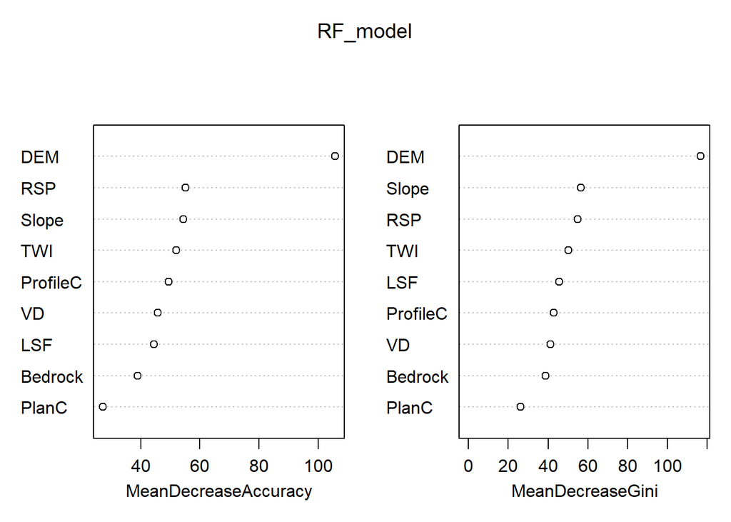

```r
sampData$soilID<-substring(as.vector(sampData$soilID),2,nchar(as.vector(sampData$soilID)))

sampData$Bedrock<-as.factor(sampData$Bedrock)
sampData$soilID<-as.factor(sampData$soilID)

RF_model<-randomForest(soilID ~.,data = sampData,
                       importance = TRUE, proximity = FALSE,ntree=1000,type="classification")

varImpPlot(RF_model)
```

```r
print(RF_model)
```

```
##
## Call:
##  randomForest(formula = soilID ~ ., data = sampData, importance = TRUE,      proximity = FALSE, ntree = 1000, type = "classification")
##                Type of random forest: classification
##                      Number of trees: 1000
## No. of variables tried at each split: 3
##
##         OOB estimate of  error rate: 25.9%
## Confusion matrix:
##     1 20 21 23  3 30 31 501 502 503  7 class.error
## 1   4  0  0  0  0  0  0   0   0   0  0   0.0000000
## 20  0 29 11  0  0  0  0   0   1  24  9   0.6081081
## 21  0 10 13  0  0  0  0   0   1   9  3   0.6388889
## 23  0  0  0 41  0  1  0   0   0   5  0   0.1276596
## 3   0  0  0  0 20  0  0   8   0   0  0   0.2857143
## 30  0  0  0  0  0 11  2   0   0   0  1   0.2142857
## 31  0  0  0  0  0  0 24   0   0   0  0   0.0000000
## 501 0  0  0  0  7  0  0  87   3   0  1   0.1122449
## 502 0  0  0  0  0  0  0   3   6   0  3   0.5000000
## 503 0  9  6  6  0  0  0   0   0 110  3   0.1791045
## 7   0  7  1  0  0  2  0   1   2   5 67   0.2117647
```

```r
map_RF <- predict(covStack, RF_model, paste(result_tif_folder,mn,".tif",sep=""),
                  format = "GTiff", datatype = "FLT4S", overwrite = TRUE)


rm("mn","shpPoint","sampData","RF_model","map_RF")
```

建模及预测—— SNA TWI ns5 25

```r
mn="All_pSNA_TWI_NS5_pen25"

shpPoint<-readOGR(paste(point_shp_folder,mn,".shp",sep = "")) ###
sampData <- extract(covStack, shpPoint, sp = TRUE,method = "simple")

sampData<-sampData@data
sampData<-na.omit(sampData)
dim(sampData)
```

```
## [1] 556  10
```

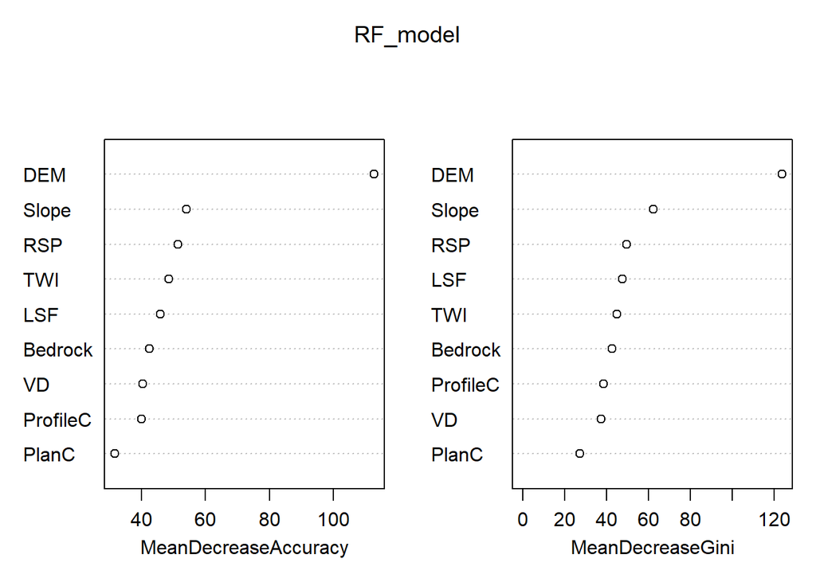

```r
sampData$soilID<-substring(as.vector(sampData$soilID),2,nchar(as.vector(sampData$soilID)))

sampData$Bedrock<-as.factor(sampData$Bedrock)
sampData$soilID<-as.factor(sampData$soilID)

RF_model<-randomForest(soilID ~.,data = sampData,
                       importance = TRUE, proximity = FALSE,ntree=1000,type="classification")

varImpPlot(RF_model)
```

```r
print(RF_model)
```

```
##
## Call:
##  randomForest(formula = soilID ~ ., data = sampData, importance = TRUE,      proximity = FALSE, ntree = 1000, type = "classification")
##                Type of random forest: classification
##                      Number of trees: 1000
## No. of variables tried at each split: 3
##
##         OOB estimate of  error rate: 23.02%
## Confusion matrix:
##     1 20 21 23  3 30 31 501 502 503  7 class.error
## 1   4  0  0  0  0  0  0   0   0   0  0  0.00000000
## 20  0 38 10  0  0  0  0   0   0  14 12  0.48648649
## 21  0 10 20  2  0  0  0   0   2   2  0  0.44444444
## 23  0  0  0 36  0  4  1   0   0   6  0  0.23404255
## 3   0  0  0  0 16  0  0  12   0   0  0  0.42857143
## 30  0  0  0  3  0  6  3   0   0   0  2  0.57142857
## 31  0  0  0  2  0  0 22   0   0   0  0  0.08333333
## 501 0  0  0  0  8  0  0  88   0   0  2  0.10204082
## 502 0  0  0  0  0  0  0   2   9   0  1  0.25000000
## 503 0  6  3  6  0  0  0   0   0 117  2  0.12686567
## 7   0  5  1  0  0  0  0   2   1   4 72  0.15294118
```

```r
map_RF <- predict(covStack, RF_model, paste(result_tif_folder,mn,".tif",sep=""),
                  format = "GTiff", datatype = "FLT4S", overwrite = TRUE)


rm("mn","shpPoint","sampData","RF_model","map_RF")
```

建模及预测—— RAN TWI 25

```r
mn="All_pRAN_TWI_pen25"

shpPoint<-readOGR(paste(point_shp_folder,mn,".shp",sep = "")) ###
sampData <- extract(covStack, shpPoint, sp = TRUE,method = "simple")

sampData<-sampData@data
sampData<-na.omit(sampData)
dim(sampData)
```

```
## [1] 556  10
```

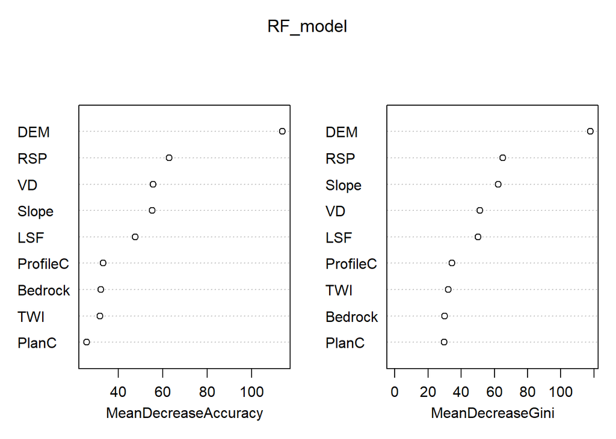

```r
sampData$soilID<-substring(as.vector(sampData$soilID),2,nchar(as.vector(sampData$soilID)))

sampData$Bedrock<-as.factor(sampData$Bedrock)
sampData$soilID<-as.factor(sampData$soilID)

RF_model<-randomForest(soilID ~.,data = sampData,
                       importance = TRUE, proximity = FALSE,ntree=1000,type="classification")

varImpPlot(RF_model)
```

```r
print(RF_model)
```

```
##
## Call:
##  randomForest(formula = soilID ~ ., data = sampData, importance = TRUE,      proximity = FALSE, ntree = 1000, type = "classification")
##                Type of random forest: classification
##                      Number of trees: 1000
## No. of variables tried at each split: 3
##
##         OOB estimate of  error rate: 28.42%
## Confusion matrix:
##     1 20 21 23  3 30 31 501 502 503  7 class.error
## 1   4  0  0  0  0  0  0   0   0   0  0   0.0000000
## 20  0 35 12  0  0  0  0   1   0  17  9   0.5270270
## 21  0 16 15  0  0  0  0   1   0   4  0   0.5833333
## 23  0  0  0 36  0  5  1   0   0   3  2   0.2340426
## 3   0  0  0  0 17  0  0  11   0   0  0   0.3928571
## 30  0  0  0  6  0  5  1   0   0   0  2   0.6428571
## 31  0  0  0  3  0  1 19   0   0   1  0   0.2083333
## 501 0  1  0  0  5  0  0  88   0   0  4   0.1020408
## 502 0  3  1  0  0  0  0   1   6   0  1   0.5000000
## 503 0 12  3  3  0  0  0   0   0 111  5   0.1716418
## 7   0  5  0  3  0  2  0   7   0   6 62   0.2705882
```

```r
map_RF <- predict(covStack, RF_model, paste(result_tif_folder,mn,".tif",sep=""),
                  format = "GTiff", datatype = "FLT4S", overwrite = TRUE)


rm("mn","shpPoint","sampData","RF_model","map_RF")
```

建模及预测—— SNA TWI ns3 75

```r
mn="All_pSNA_TWI_NS3_pen75"

shpPoint<-readOGR(paste(point_shp_folder,mn,".shp",sep = "")) ###
sampData <- extract(covStack, shpPoint, sp = TRUE,method = "simple")

sampData<-sampData@data
sampData<-na.omit(sampData)
dim(sampData)
```

```
## [1] 1543   10
```

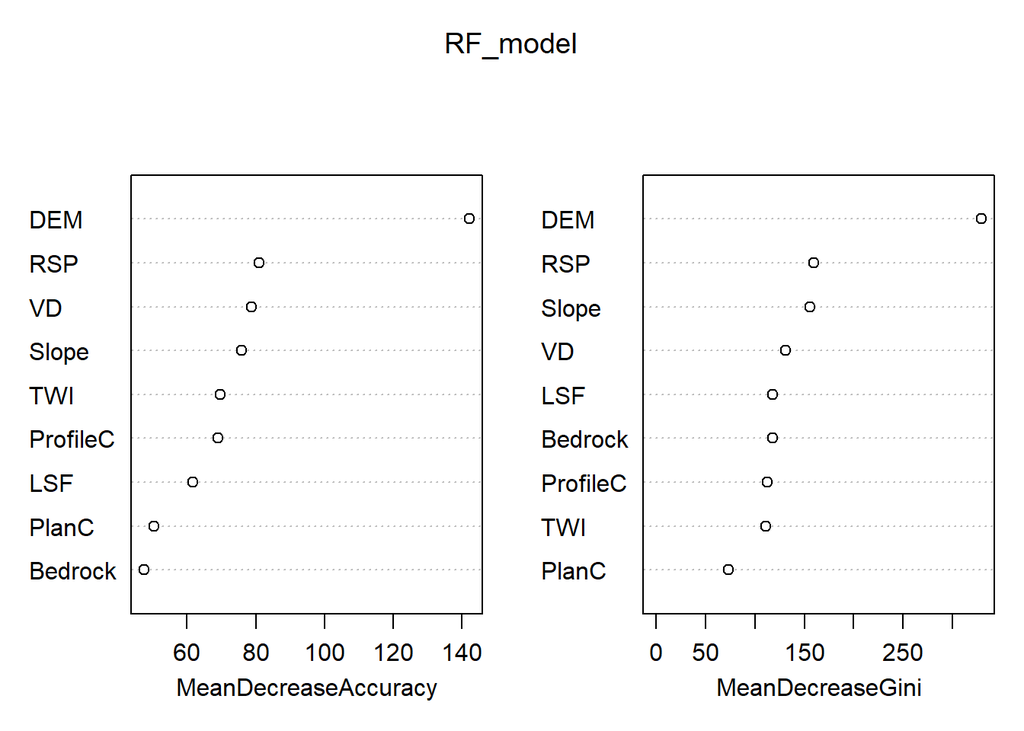

```r
sampData$soilID<-substring(as.vector(sampData$soilID),2,nchar(as.vector(sampData$soilID)))

sampData$Bedrock<-as.factor(sampData$Bedrock)
sampData$soilID<-as.factor(sampData$soilID)

RF_model<-randomForest(soilID ~.,data = sampData,
                       importance = TRUE, proximity = FALSE,ntree=1000,type="classification")

varImpPlot(RF_model)
```

```r
print(RF_model)
```

```
##
## Call:
##  randomForest(formula = soilID ~ ., data = sampData, importance = TRUE,      proximity = FALSE, ntree = 1000, type = "classification")
##                Type of random forest: classification
##                      Number of trees: 1000
## No. of variables tried at each split: 3
##
##         OOB estimate of  error rate: 19.96%
## Confusion matrix:
##     1  20 21  23  3 30 31 501 502 503   7 class.error
## 1   9   0  0   0  1  0  0   0   0   0   0  0.10000000
## 20  0 112 17   1  0  0  0   0   2  43  20  0.42564103
## 21  0  24 37   0  0  0  0   0   0  14   0  0.50666667
## 23  0   0  0 110  0  6  5   0   0  12   0  0.17293233
## 3   3   0  0   0 55  0  0  25   0   0   0  0.33734940
## 30  0   0  0   3  0 28  2   0   0   0   3  0.22222222
## 31  0   0  0   2  0  1 65   0   0   2   0  0.07142857
## 501 0   1  0   0 23  0  0 258   2   0   7  0.11340206
## 502 0   1  0   0  0  0  0   1  25   0   4  0.19354839
## 503 0  21  7  15  0  0  0   0   0 331   7  0.13123360
## 7   0  11  1   0  0  2  0   9   3   7 205  0.13865546
```

```r
map_RF <- predict(covStack, RF_model, paste(result_tif_folder,mn,".tif",sep=""),
                  format = "GTiff", datatype = "FLT4S", overwrite = TRUE)


rm("mn","shpPoint","sampData","RF_model","map_RF")
```

建模及预测—— SNA TWI ns5 75

```r
mn="All_pSNA_TWI_NS5_pen75"

shpPoint<-readOGR(paste(point_shp_folder,mn,".shp",sep = "")) ###
sampData <- extract(covStack, shpPoint, sp = TRUE,method = "simple")

sampData<-sampData@data
sampData<-na.omit(sampData)
dim(sampData)
```

```
## [1] 1543   10
```

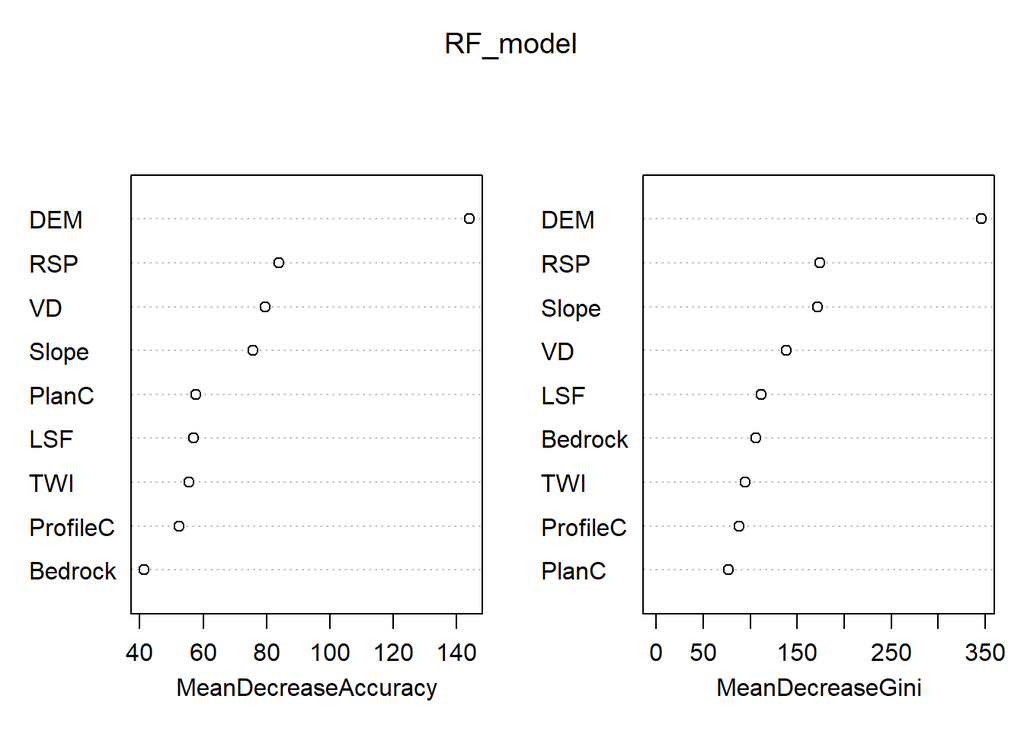

```r
sampData$soilID<-substring(as.vector(sampData$soilID),2,nchar(as.vector(sampData$soilID)))

sampData$Bedrock<-as.factor(sampData$Bedrock)
sampData$soilID<-as.factor(sampData$soilID)

RF_model<-randomForest(soilID ~.,data = sampData,
                       importance = TRUE, proximity = FALSE,ntree=1000,type="classification")

varImpPlot(RF_model)
```

```r
print(RF_model)
```

```
##
## Call:
##  randomForest(formula = soilID ~ ., data = sampData, importance = TRUE,      proximity = FALSE, ntree = 1000, type = "classification")
##                Type of random forest: classification
##                      Number of trees: 1000
## No. of variables tried at each split: 3
##
##         OOB estimate of  error rate: 19.57%
## Confusion matrix:
##     1  20 21  23  3 30 31 501 502 503   7 class.error
## 1   8   0  0   0  2  0  0   0   0   0   0  0.20000000
## 20  0 117 15   0  0  0  0   1   2  34  26  0.40000000
## 21  0  21 49   0  0  0  0   0   1   4   0  0.34666667
## 23  0   0  0 100  0  6  5   0   0  19   3  0.24812030
## 3   2   0  0   0 55  0  0  26   0   0   0  0.33734940
## 30  0   0  0   5  0 25  5   0   0   0   1  0.30555556
## 31  0   0  0   7  0  4 58   0   0   1   0  0.17142857
## 501 0   0  0   0 21  0  0 261   0   0   9  0.10309278
## 502 0   1  0   0  0  0  0   3  23   0   4  0.25806452
## 503 0  17  2  10  0  0  0   0   0 345   7  0.09448819
## 7   0  12  1   0  0  2  0  10   2  11 200  0.15966387
```

```r
map_RF <- predict(covStack, RF_model, paste(result_tif_folder,mn,".tif",sep=""),
                  format = "GTiff", datatype = "FLT4S", overwrite = TRUE)

rm("mn","shpPoint","sampData","RF_model","map_RF")
```

建模及预测—— RAN TWI 75

```r
mn="All_pRAN_TWI_pen75"

shpPoint<-readOGR(paste(point_shp_folder,mn,".shp",sep = "")) ###
sampData <- extract(covStack, shpPoint, sp = TRUE,method = "simple")

sampData<-sampData@data
sampData<-na.omit(sampData)
dim(sampData)
```

```
## [1] 1542   10
```

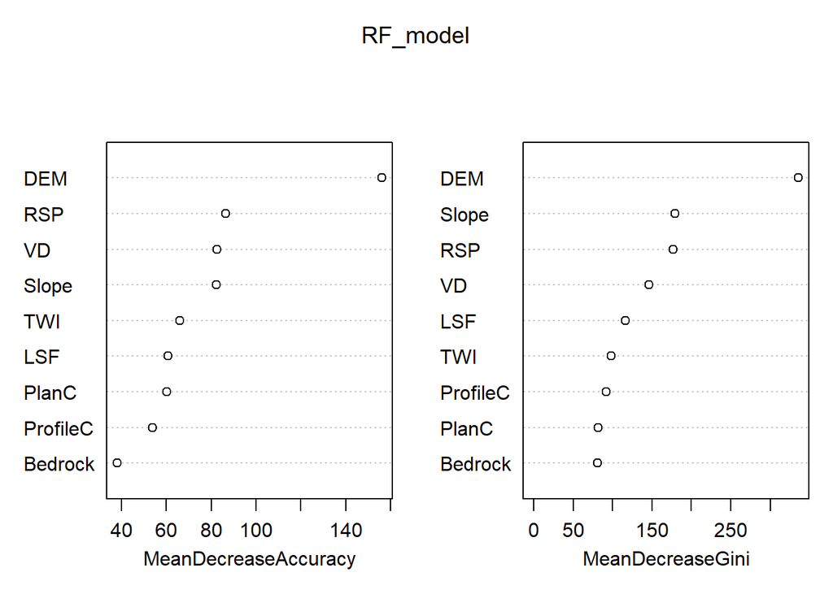

```r
sampData$soilID<-substring(as.vector(sampData$soilID),2,nchar(as.vector(sampData$soilID)))

sampData$Bedrock<-as.factor(sampData$Bedrock)
sampData$soilID<-as.factor(sampData$soilID)

RF_model<-randomForest(soilID ~.,data = sampData,
                       importance = TRUE, proximity = FALSE,ntree=1000,type="classification")

varImpPlot(RF_model)
```

```r
print(RF_model)
```

```
##
## Call:
##  randomForest(formula = soilID ~ ., data = sampData, importance = TRUE,      proximity = FALSE, ntree = 1000, type = "classification")
##                Type of random forest: classification
##                      Number of trees: 1000
## No. of variables tried at each split: 3
##
##         OOB estimate of  error rate: 20.88%
## Confusion matrix:
##     1  20 21 23  3 30 31 501 502 503   7 class.error
## 1   8   0  0  0  1  0  0   0   0   0   0  0.11111111
## 20  0 123 13  1  0  0  0   2   2  31  23  0.36923077
## 21  0  24 42  0  0  0  0   2   0   6   1  0.44000000
## 23  0   0  0 95  0  5  4   0   0  22   7  0.28571429
## 3   1   0  0  0 61  0  0  21   0   0   0  0.26506024
## 30  0   0  0 11  0 19  3   0   0   0   3  0.47222222
## 31  0   0  0  9  0  4 56   0   0   1   0  0.20000000
## 501 0   1  0  0 12  0  0 269   0   0   9  0.07560137
## 502 0   6  1  0  0  0  0   2  18   1   3  0.41935484
## 503 0  20  2 14  0  0  0   0   0 335  10  0.12073491
## 7   0  21  0  2  0  1  0   8   1  11 194  0.18487395
```

```r
map_RF <- predict(covStack, RF_model, paste(result_tif_folder,mn,".tif",sep=""),
                  format = "GTiff", datatype = "FLT4S", overwrite = TRUE)


rm("mn","shpPoint","sampData","RF_model","map_RF")
```

# 单因子计算精度

```r
#设置最终结果tif的保存路径
result_tif_folder="E:/otherWork/02_1/soil2019-rewrite/result_mapTif/"

result_map_name<-c("All_pSNA_DEM_NS3_pen25","All_pSNA_DEM_NS3_pen75",
                   "All_pSNA_DEM_NS5_pen25","All_pSNA_DEM_NS5_pen75",
                   "All_pRAN_DEM_pen25","All_pRAN_DEM_pen75",
                   "All_pSNA_Slope_NS3_pen25","All_pSNA_Slope_NS3_pen75",
                   "All_pSNA_Slope_NS5_pen25","All_pSNA_Slope_NS5_pen75",
                   "All_pRAN_Slope_pen25","All_pRAN_Slope_pen75",
                   "All_pSNA_PlanC_NS3_pen25","All_pSNA_PlanC_NS3_pen75",
                   "All_pSNA_PlanC_NS5_pen25","All_pSNA_PlanC_NS5_pen75",
                   "All_pRAN_PlanC_pen25","All_pRAN_PlanC_pen75",
                   "All_pSNA_TWI_NS3_pen25","All_pSNA_TWI_NS3_pen75",
                   "All_pSNA_TWI_NS5_pen25","All_pSNA_TWI_NS5_pen75",
                   "All_pRAN_TWI_pen25","All_pRAN_TWI_pen75")

resultCovStack<-raster(paste(result_tif_folder,result_map_name[1],".tif",sep = ""))
for (i in 2:length(result_map_name)) {
  resultCovStack <- stack(resultCovStack, paste(result_tif_folder,result_map_name[i],".tif",sep = ""))
}

validationPoint<-readOGR(paste(result_tif_folder,"validationPoint.shp",sep = "")) ###
```

```r
vp_data <- extract(resultCovStack, validationPoint, sp = TRUE,method = "simple")
vp_data<-na.omit(vp_data@data)

hsm<-raster(paste(result_tif_folder,"historical_soil_map.tif",sep = ""))
soil_type<- unique(hsm)
vp_data<-vp_data[vp_data$trueType %in% soil_type,]

print(nrow(vp_data))
```

```
## [1] 92
```

```r
precision_df<-data.frame("method"=rep(NA,length(result_map_name)),
                         "factor"=rep(NA,length(result_map_name)),
                         "NS"=rep(NA,length(result_map_name)),
                         "percent"=rep(NA,length(result_map_name)),
                         "precisionValue"=rep(NA,length(result_map_name)))

for (i in 1:length(result_map_name)){
  fna<-result_map_name[i]
  ns_split<-unlist(strsplit(fna,"_"))
  if (length(ns_split)==5){
    precision_df[i,]$method<-ns_split[2]
    precision_df[i,]$factor<-ns_split[3]
    precision_df[i,]$NS<-ns_split[4]
    precision_df[i,]$percent<-ns_split[5]
    precision_df[i,]$precisionValue<-round( sum(vp_data$trueType==vp_data[fna])/nrow(vp_data),4)
  }
  else{
    precision_df[i,]$method<-ns_split[2]
    precision_df[i,]$factor<-ns_split[3]
    precision_df[i,]$NS<-"RAN"
    precision_df[i,]$percent<-ns_split[4]
    precision_df[i,]$precisionValue<-round( sum(vp_data$trueType==vp_data[fna])/nrow(vp_data),4)
  }
}

precision_oldSoilMap<-round( sum(vp_data$trueType==vp_data$oldSoilMap)/nrow(vp_data),4)
print(precision_oldSoilMap)
```

```
## [1] 0.6196
```

```r
print(precision_df)
```

```
##    method factor  NS percent precisionValue
## 1    pSNA    DEM NS3   pen25         0.3043
## 2    pSNA    DEM NS3   pen75         0.3478
## 3    pSNA    DEM NS5   pen25         0.3696
## 4    pSNA    DEM NS5   pen75         0.5978
## 5    pRAN    DEM RAN   pen25         0.5761
## 6    pRAN    DEM RAN   pen75         0.6413
## 7    pSNA  Slope NS3   pen25         0.6957
## 8    pSNA  Slope NS3   pen75         0.6957
## 9    pSNA  Slope NS5   pen25         0.6522
## 10   pSNA  Slope NS5   pen75         0.6739
## 11   pRAN  Slope RAN   pen25         0.5652
## 12   pRAN  Slope RAN   pen75         0.6196
## 13   pSNA  PlanC NS3   pen25         0.5870
## 14   pSNA  PlanC NS3   pen75         0.5870
## 15   pSNA  PlanC NS5   pen25         0.6304
## 16   pSNA  PlanC NS5   pen75         0.6522
## 17   pRAN  PlanC RAN   pen25         0.6304
## 18   pRAN  PlanC RAN   pen75         0.6522
## 19   pSNA    TWI NS3   pen25         0.6739
## 20   pSNA    TWI NS3   pen75         0.6522
## 21   pSNA    TWI NS5   pen25         0.7283
## 22   pSNA    TWI NS5   pen75         0.6957
## 23   pRAN    TWI RAN   pen25         0.6196
## 24   pRAN    TWI RAN   pen75         0.6304
```

```r
rm("result_map_name")
```

# 多因子分析

DEM+Slope+PlanC ns3 25 -TWI

```r
#
mn1="All_pSNA_DEM_NS3_pen25"
shpPoint1<-readOGR(paste(point_shp_folder,mn1,".shp",sep = "")) ###
sampData1 <- extract(covStack, shpPoint1, sp = TRUE,method = "simple")
sampData1<-sampData1@data
#
mn2="All_pSNA_Slope_NS3_pen25"
shpPoint2<-readOGR(paste(point_shp_folder,mn2,".shp",sep = "")) ###
sampData2 <- extract(covStack, shpPoint2, sp = TRUE,method = "simple")
sampData2<-sampData2@data
#
mn3="All_pSNA_PlanC_NS3_pen25"
shpPoint3<-readOGR(paste(point_shp_folder,mn3,".shp",sep = "")) ###
```

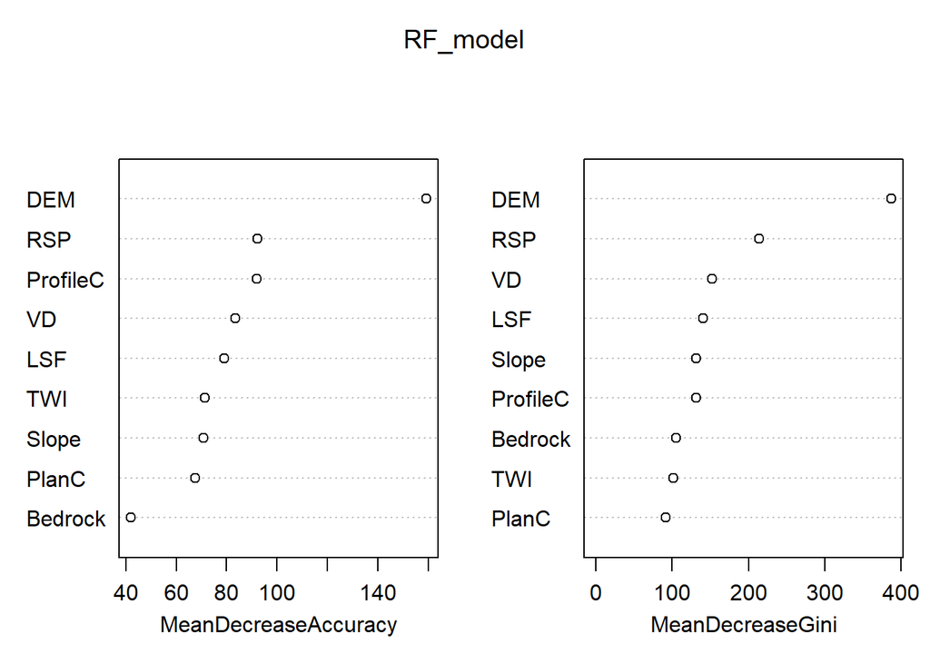

```r
sampData3 <- extract(covStack, shpPoint3, sp = TRUE,method = "simple")
sampData3<-sampData3@data

sampData<-rbind(sampData1,sampData2,sampData3)
sampData<-na.omit(sampData)

sampData$soilID<-substring(as.vector(sampData$soilID),2,nchar(as.vector(sampData$soilID)))

sampData$Bedrock<-as.factor(sampData$Bedrock)
sampData$soilID<-as.factor(sampData$soilID)

RF_model<-randomForest(soilID ~.,data = sampData,
                       importance = TRUE, proximity = FALSE,ntree=1000,type="classification")

varImpPlot(RF_model)
```

```r
print(RF_model)
```

```
##
## Call:
##  randomForest(formula = soilID ~ ., data = sampData, importance = TRUE,      proximity = FALSE, ntree = 1000, type = "classification")
##                Type of random forest: classification
##                      Number of trees: 1000
## No. of variables tried at each split: 3
##
##         OOB estimate of  error rate: 18.43%
## Confusion matrix:
##     1  20 21  23  3 30 31 501 502 503   7 class.error
## 1   1   0  0   0  5  0  0   0   0   0   0  0.83333333
## 20  0 150 15   0  0  0  0   5   1  35  26  0.35344828
## 21  0  27 70   0  0  0  0   0   3   8   1  0.35779817
## 23  0   0  0 121  0  5  1   0   0  15   2  0.15972222
## 3   1   0  0   0 75  0  0  18   0   0   0  0.20212766
## 30  0   0  0  13  0 26  0   0   0   0   3  0.38095238
## 31  0   0  0   8  0  0 58   0   0   0   0  0.12121212
## 501 0   4  0   0 13  0  0 296   1   0   3  0.06624606
## 502 0   3  3   0  0  0  0   5  20   1   5  0.45945946
## 503 0  22  2   7  0  0  0   0   0 362  14  0.11056511
## 7   0  11  1   0  0  1  0  10   2  15 215  0.15686275
```

```r
map_RF <- predict(covStack, RF_model, paste(result_tif_folder,"SNA_NS3_DEM0Slope0PlanC.tif",sep=""),
                  format = "GTiff", datatype = "FLT4S", overwrite = TRUE)


rm("mn1","shpPoint1","sampData1","mn2","shpPoint2","sampData2","mn3","shpPoint3","sampData3","sampData","RF_model","map_RF")
```

DEM+Slope+PlanC ns5 25 -TWI

```r
#
mn1="All_pSNA_DEM_NS5_pen25"
shpPoint1<-readOGR(paste(point_shp_folder,mn1,".shp",sep = "")) ###
sampData1 <- extract(covStack, shpPoint1, sp = TRUE,method = "simple")
sampData1<-sampData1@data
#
mn2="All_pSNA_Slope_NS5_pen25"
shpPoint2<-readOGR(paste(point_shp_folder,mn2,".shp",sep = "")) ###
sampData2 <- extract(covStack, shpPoint2, sp = TRUE,method = "simple")
sampData2<-sampData2@data
#
mn3="All_pSNA_PlanC_NS5_pen25"
shpPoint3<-readOGR(paste(point_shp_folder,mn3,".shp",sep = "")) ###
```

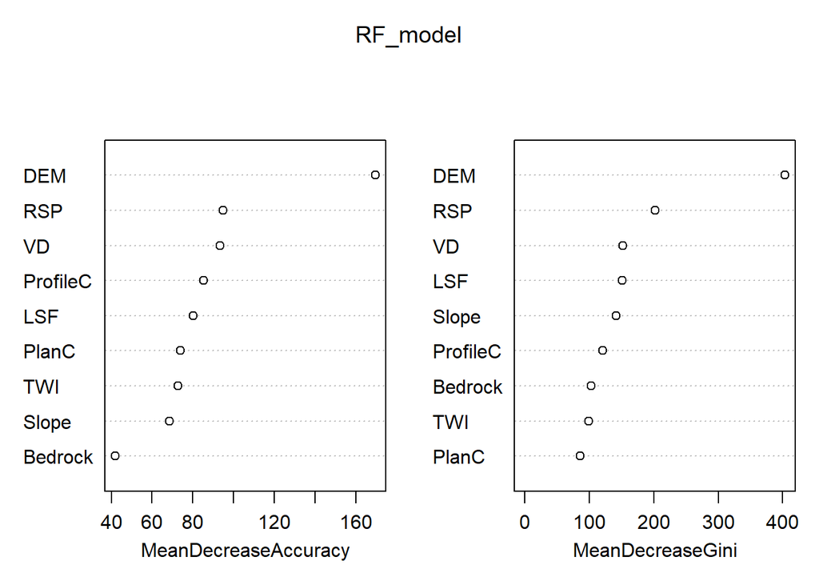

```r
sampData3 <- extract(covStack, shpPoint3, sp = TRUE,method = "simple")
sampData3<-sampData3@data

sampData<-rbind(sampData1,sampData2,sampData3)
sampData<-na.omit(sampData)

sampData$soilID<-substring(as.vector(sampData$soilID),2,nchar(as.vector(sampData$soilID)))

sampData$Bedrock<-as.factor(sampData$Bedrock)
sampData$soilID<-as.factor(sampData$soilID)

RF_model<-randomForest(soilID ~.,data = sampData,
                       importance = TRUE, proximity = FALSE,ntree=1000,type="classification")

varImpPlot(RF_model)
```

```r
print(RF_model)
```

```
##
## Call:
##  randomForest(formula = soilID ~ ., data = sampData, importance = TRUE,      proximity = FALSE, ntree = 1000, type = "classification")
##                Type of random forest: classification
##                      Number of trees: 1000
## No. of variables tried at each split: 3
##
##         OOB estimate of  error rate: 14.14%
## Confusion matrix:
##     1  20 21  23  3 30 31 501 502 503   7 class.error
## 1   5   0  0   0  4  0  0   0   0   0   0  0.44444444
## 20  0 175  6   0  0  0  0   3   0  32  16  0.24568966
## 21  0  22 80   0  0  0  0   1   1   5   0  0.26605505
## 23  0   0  0 119  0  7  1   0   0  15   2  0.17361111
## 3   0   0  0   0 80  0  0  14   0   0   0  0.14893617
## 30  0   0  0   9  0 32  0   0   0   0   1  0.23809524
## 31  0   0  0   3  0  0 63   0   0   0   0  0.04545455
## 501 0   2  0   0 15  0  0 297   1   0   2  0.06309148
## 502 0   3  2   0  0  0  0   3  27   1   1  0.27027027
## 503 0  14  1   3  0  0  0   0   0 381   8  0.06388206
## 7   0  11  0   1  0  2  0   9   0  21 211  0.17254902
```

```r
map_RF <- predict(covStack, RF_model, paste(result_tif_folder,"SNA_NS5_DEM0Slope0PlanC.tif",sep=""),
                  format = "GTiff", datatype = "FLT4S", overwrite = TRUE)


rm("mn1","shpPoint1","sampData1","mn2","shpPoint2","sampData2","mn3","shpPoint3","sampData3","sampData","RF_model","map_RF")
```

DEM+Slope+TWI ns3 25 -PlanC

```r
#
mn1="All_pSNA_DEM_NS3_pen25"
shpPoint1<-readOGR(paste(point_shp_folder,mn1,".shp",sep = "")) ###
sampData1 <- extract(covStack, shpPoint1, sp = TRUE,method = "simple")
sampData1<-sampData1@data
#
mn2="All_pSNA_Slope_NS3_pen25"
shpPoint2<-readOGR(paste(point_shp_folder,mn2,".shp",sep = "")) ###
sampData2 <- extract(covStack, shpPoint2, sp = TRUE,method = "simple")
sampData2<-sampData2@data
#
mn3="All_pSNA_TWI_NS3_pen25"
shpPoint3<-readOGR(paste(point_shp_folder,mn3,".shp",sep = "")) ###
```

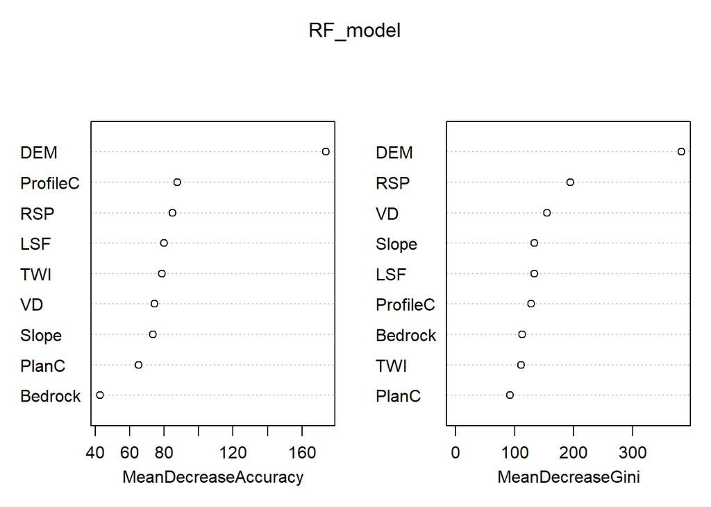

```r
sampData3 <- extract(covStack, shpPoint3, sp = TRUE,method = "simple")
sampData3<-sampData3@data

sampData<-rbind(sampData1,sampData2,sampData3)
sampData<-na.omit(sampData)

sampData$soilID<-substring(as.vector(sampData$soilID),2,nchar(as.vector(sampData$soilID)))

sampData$Bedrock<-as.factor(sampData$Bedrock)
sampData$soilID<-as.factor(sampData$soilID)

RF_model<-randomForest(soilID ~.,data = sampData,
                       importance = TRUE, proximity = FALSE,ntree=1000,type="classification")

varImpPlot(RF_model)
```

```r
print(RF_model)
```

```
##
## Call:
##  randomForest(formula = soilID ~ ., data = sampData, importance = TRUE,      proximity = FALSE, ntree = 1000, type = "classification")
##                Type of random forest: classification
##                      Number of trees: 1000
## No. of variables tried at each split: 3
##
##         OOB estimate of  error rate: 18.51%
## Confusion matrix:
##     1  20 21  23  3 30 31 501 502 503   7 class.error
## 1   4   0  0   0  3  0  0   0   0   0   0  0.42857143
## 20  0 137 16   0  0  0  0   2   1  46  27  0.40174672
## 21  0  24 61   0  0  0  0   0   0  23   2  0.44545455
## 23  0   0  0 126  0  5  3   0   0   7   2  0.11888112
## 3   1   0  0   0 68  0  0  23   0   0   0  0.26086957
## 30  0   0  0   9  0 28  2   0   0   1   2  0.33333333
## 31  0   0  0   7  0  1 59   0   0   0   0  0.11940299
## 501 0   1  0   0 13  0  0 289   2   0   4  0.06472492
## 502 0   1  2   0  0  0  0   3  25   1   5  0.32432432
## 503 0  19  5   4  0  1  0   0   0 367  11  0.09828010
## 7   0  12  0   0  0  2  0   5   2  14 218  0.13833992
```

```r
map_RF <- predict(covStack, RF_model, paste(result_tif_folder,"SNA_NS3_DEM0Slope0TWI.tif",sep=""),
                  format = "GTiff", datatype = "FLT4S", overwrite = TRUE)


rm("mn1","shpPoint1","sampData1","mn2","shpPoint2","sampData2","mn3","shpPoint3","sampData3","sampData","RF_model","map_RF")
```

DEM+Slope+TWI ns5 25 -PlanC

```r
#
mn1="All_pSNA_DEM_NS5_pen25"
shpPoint1<-readOGR(paste(point_shp_folder,mn1,".shp",sep = "")) ###
sampData1 <- extract(covStack, shpPoint1, sp = TRUE,method = "simple")
sampData1<-sampData1@data
#
mn2="All_pSNA_Slope_NS5_pen25"
shpPoint2<-readOGR(paste(point_shp_folder,mn2,".shp",sep = "")) ###
sampData2 <- extract(covStack, shpPoint2, sp = TRUE,method = "simple")
sampData2<-sampData2@data
#
mn3="All_pSNA_TWI_NS5_pen25"
shpPoint3<-readOGR(paste(point_shp_folder,mn3,".shp",sep = "")) ###
```

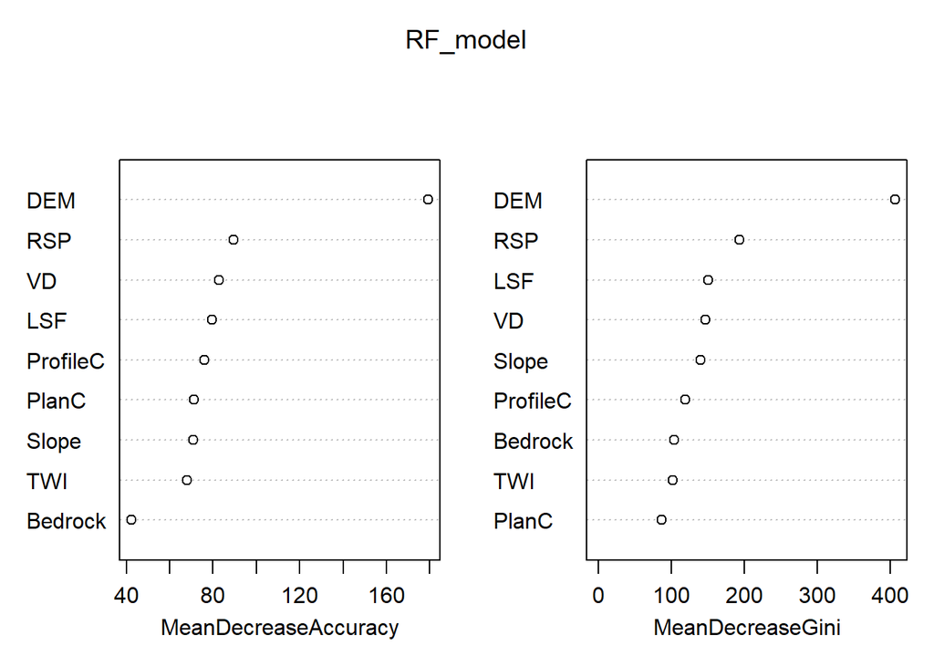

```r
sampData3 <- extract(covStack, shpPoint3, sp = TRUE,method = "simple")
sampData3<-sampData3@data

sampData<-rbind(sampData1,sampData2,sampData3)
sampData<-na.omit(sampData)

sampData$soilID<-substring(as.vector(sampData$soilID),2,nchar(as.vector(sampData$soilID)))

sampData$Bedrock<-as.factor(sampData$Bedrock)
sampData$soilID<-as.factor(sampData$soilID)

RF_model<-randomForest(soilID ~.,data = sampData,
                       importance = TRUE, proximity = FALSE,ntree=1000,type="classification")

varImpPlot(RF_model)
```

```r
print(RF_model)
```

```
##
## Call:
##  randomForest(formula = soilID ~ ., data = sampData, importance = TRUE,      proximity = FALSE, ntree = 1000, type = "classification")
##                Type of random forest: classification
##                      Number of trees: 1000
## No. of variables tried at each split: 3
##
##         OOB estimate of  error rate: 15.54%
## Confusion matrix:
##     1  20 21  23  3 30 31 501 502 503   7 class.error
## 1   8   0  0   0  2  0  0   0   0   0   0  0.20000000
## 20  0 160 11   0  0  0  0   3   0  31  24  0.30131004
## 21  0  18 86   0  0  0  0   1   0   3   2  0.21818182
## 23  0   0  0 125  0  7  2   0   0   9   0  0.12587413
## 3   1   0  0   0 70  0  0  21   0   0   0  0.23913043
## 30  0   0  0  10  0 28  1   0   0   0   3  0.33333333
## 31  0   0  0   5  0  0 61   0   0   0   1  0.08955224
## 501 0   1  0   0 15  0  0 288   1   0   4  0.06796117
## 502 0   2  2   0  0  0  0   3  29   0   1  0.21621622
## 503 0  20  5   7  0  0  0   0   0 364  11  0.10565111
## 7   0  13  0   1  0  3  0   8   0  12 216  0.14624506
```

```r
map_RF <- predict(covStack, RF_model, paste(result_tif_folder,"SNA_NS5_DEM0Slope0TWI.tif",sep=""),
                  format = "GTiff", datatype = "FLT4S", overwrite = TRUE)


rm("mn1","shpPoint1","sampData1","mn2","shpPoint2","sampData2","mn3","shpPoint3","sampData3","sampData","RF_model","map_RF")
```

DEM+PlanC+TWI ns3 25 -Slope

```r
#
mn1="All_pSNA_DEM_NS3_pen25"
shpPoint1<-readOGR(paste(point_shp_folder,mn1,".shp",sep = "")) ###
sampData1 <- extract(covStack, shpPoint1, sp = TRUE,method = "simple")
sampData1<-sampData1@data
#
mn2="All_pSNA_PlanC_NS3_pen25"
shpPoint2<-readOGR(paste(point_shp_folder,mn2,".shp",sep = "")) ###
sampData2 <- extract(covStack, shpPoint2, sp = TRUE,method = "simple")
sampData2<-sampData2@data
#
mn3="All_pSNA_TWI_NS3_pen25"
shpPoint3<-readOGR(paste(point_shp_folder,mn3,".shp",sep = "")) ###
```

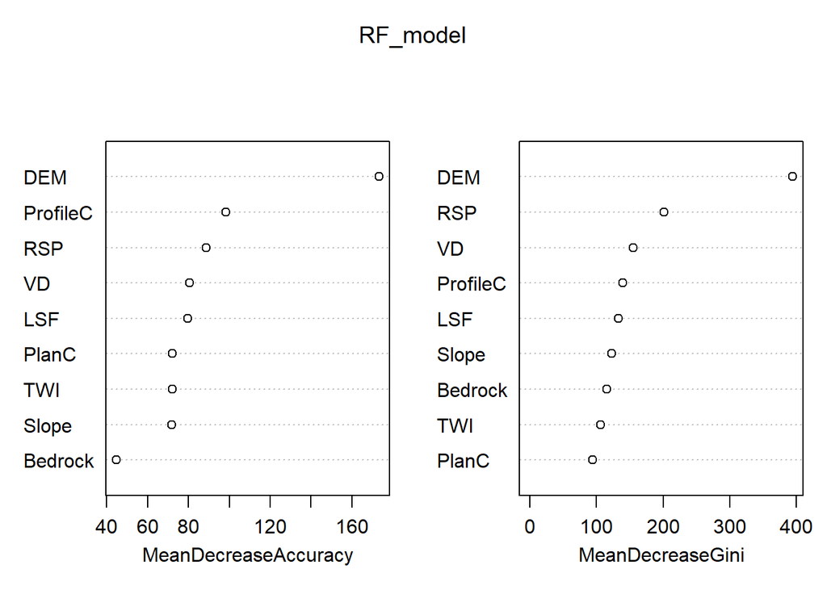

```r
sampData3 <- extract(covStack, shpPoint3, sp = TRUE,method = "simple")
sampData3<-sampData3@data

sampData<-rbind(sampData1,sampData2,sampData3)
sampData<-na.omit(sampData)

sampData$soilID<-substring(as.vector(sampData$soilID),2,nchar(as.vector(sampData$soilID)))

sampData$Bedrock<-as.factor(sampData$Bedrock)
sampData$soilID<-as.factor(sampData$soilID)

RF_model<-randomForest(soilID ~.,data = sampData,
                       importance = TRUE, proximity = FALSE,ntree=1000,type="classification")

varImpPlot(RF_model)
```

```r
print(RF_model)
```

```
##
## Call:
##  randomForest(formula = soilID ~ ., data = sampData, importance = TRUE,      proximity = FALSE, ntree = 1000, type = "classification")
##                Type of random forest: classification
##                      Number of trees: 1000
## No. of variables tried at each split: 3
##
##         OOB estimate of  error rate: 18.41%
## Confusion matrix:
##     1  20 21  23  3 30 31 501 502 503   7 class.error
## 1   4   0  0   0  4  0  0   0   0   0   0  0.50000000
## 20  0 134 21   0  0  0  0   1   0  52  22  0.41739130
## 21  0  22 70   0  0  0  0   0   0  17   0  0.35779817
## 23  0   0  0 125  0  7  1   0   0  12   1  0.14383562
## 3   0   0  0   0 71  0  0  20   0   0   0  0.21978022
## 30  0   0  0  13  0 26  0   0   0   0   3  0.38095238
## 31  0   0  0  10  0  1 58   0   0   0   0  0.15942029
## 501 0   2  0   0 13  0  0 292   2   0   5  0.07006369
## 502 0   2  0   0  0  0  0   4  25   1   5  0.32432432
## 503 0  16  2   7  0  1  0   0   0 373  12  0.09245742
## 7   0  14  0   0  0  1  0   6   3  13 222  0.14285714
```

```r
map_RF <- predict(covStack, RF_model, paste(result_tif_folder,"SNA_NS3_DEM0PlanC0TWI.tif",sep=""),
                  format = "GTiff", datatype = "FLT4S", overwrite = TRUE)


rm("mn1","shpPoint1","sampData1","mn2","shpPoint2","sampData2","mn3","shpPoint3","sampData3","sampData","RF_model","map_RF")
```

DEM+PlanC+TWI ns5 25 -Slope

```r
#
mn1="All_pSNA_DEM_NS5_pen25"
shpPoint1<-readOGR(paste(point_shp_folder,mn1,".shp",sep = "")) ###
sampData1 <- extract(covStack, shpPoint1, sp = TRUE,method = "simple")
sampData1<-sampData1@data
#
mn2="All_pSNA_PlanC_NS5_pen25"
shpPoint2<-readOGR(paste(point_shp_folder,mn2,".shp",sep = "")) ###
sampData2 <- extract(covStack, shpPoint2, sp = TRUE,method = "simple")
sampData2<-sampData2@data
#
mn3="All_pSNA_TWI_NS5_pen25"
shpPoint3<-readOGR(paste(point_shp_folder,mn3,".shp",sep = "")) ###
```

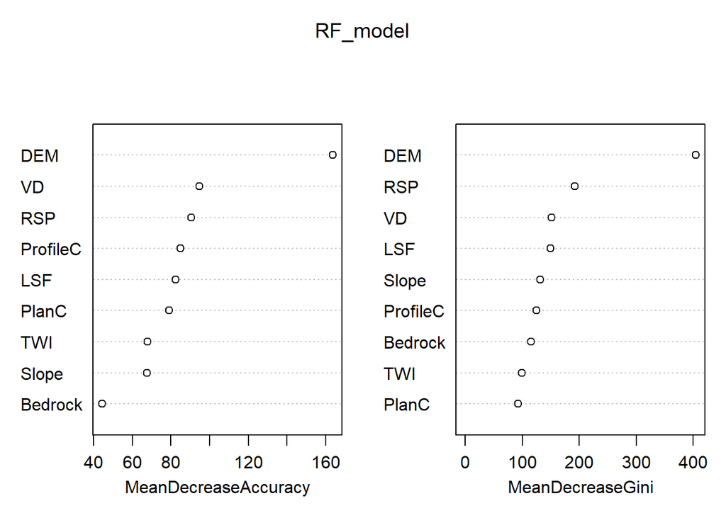

```r
sampData3 <- extract(covStack, shpPoint3, sp = TRUE,method = "simple")
sampData3<-sampData3@data

sampData<-rbind(sampData1,sampData2,sampData3)
sampData<-na.omit(sampData)

sampData$soilID<-substring(as.vector(sampData$soilID),2,nchar(as.vector(sampData$soilID)))

sampData$Bedrock<-as.factor(sampData$Bedrock)
sampData$soilID<-as.factor(sampData$soilID)

RF_model<-randomForest(soilID ~.,data = sampData,
                       importance = TRUE, proximity = FALSE,ntree=1000,type="classification")

varImpPlot(RF_model)
```

```r
print(RF_model)
```

```
##
## Call:
##  randomForest(formula = soilID ~ ., data = sampData, importance = TRUE,      proximity = FALSE, ntree = 1000, type = "classification")
##                Type of random forest: classification
##                      Number of trees: 1000
## No. of variables tried at each split: 3
##
##         OOB estimate of  error rate: 13.92%
## Confusion matrix:
##     1  20 21  23  3 30 31 501 502 503   7 class.error
## 1   6   0  0   0  3  0  0   0   0   0   0  0.33333333
## 20  0 165 13   0  0  0  0   0   0  29  23  0.28260870
## 21  0  14 91   0  0  0  0   0   0   3   1  0.16513761
## 23  0   0  0 118  0  9  0   0   0  18   1  0.19178082
## 3   0   0  0   0 72  0  0  19   0   0   0  0.20879121
## 30  0   0  0  11  0 26  0   0   0   0   5  0.38095238
## 31  0   0  0   3  0  0 65   0   0   1   0  0.05797101
## 501 0   1  0   0  9  0  0 302   0   0   2  0.03821656
## 502 0   2  1   0  0  0  0   4  27   1   2  0.27027027
## 503 0  18  2   3  0  0  0   0   0 381   7  0.07299270
## 7   0  11  1   1  0  2  0   7   0  12 225  0.13127413
```

```r
map_RF <- predict(covStack, RF_model, paste(result_tif_folder,"SNA_NS5_DEM0PlanC0TWI.tif",sep=""),
                  format = "GTiff", datatype = "FLT4S", overwrite = TRUE)


rm("mn1","shpPoint1","sampData1","mn2","shpPoint2","sampData2","mn3","shpPoint3","sampData3","sampData","RF_model","map_RF")
```

Slope+PlanC+TWI ns3 25 -DEM

```r
#
mn1="All_pSNA_Slope_NS3_pen25"
shpPoint1<-readOGR(paste(point_shp_folder,mn1,".shp",sep = "")) ###
sampData1 <- extract(covStack, shpPoint1, sp = TRUE,method = "simple")
sampData1<-sampData1@data
#
mn2="All_pSNA_PlanC_NS3_pen25"
shpPoint2<-readOGR(paste(point_shp_folder,mn2,".shp",sep = "")) ###
sampData2 <- extract(covStack, shpPoint2, sp = TRUE,method = "simple")
sampData2<-sampData2@data
#
mn3="All_pSNA_TWI_NS3_pen25"
shpPoint3<-readOGR(paste(point_shp_folder,mn3,".shp",sep = "")) ###
```

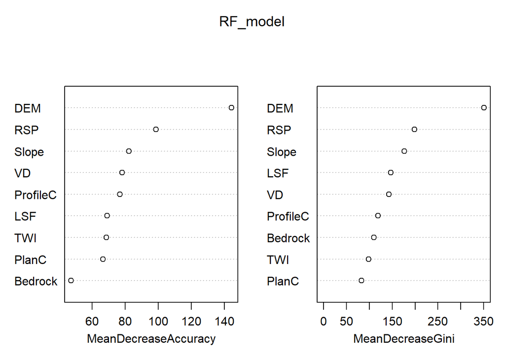

```r
sampData3 <- extract(covStack, shpPoint3, sp = TRUE,method = "simple")
sampData3<-sampData3@data

sampData<-rbind(sampData1,sampData2,sampData3)
sampData<-na.omit(sampData)

sampData$soilID<-substring(as.vector(sampData$soilID),2,nchar(as.vector(sampData$soilID)))

sampData$Bedrock<-as.factor(sampData$Bedrock)
sampData$soilID<-as.factor(sampData$soilID)

RF_model<-randomForest(soilID ~.,data = sampData,
                       importance = TRUE, proximity = FALSE,ntree=1000,type="classification")

varImpPlot(RF_model)
```

```r
print(RF_model)
```

```
##
## Call:
##  randomForest(formula = soilID ~ ., data = sampData, importance = TRUE,      proximity = FALSE, ntree = 1000, type = "classification")
##                Type of random forest: classification
##                      Number of trees: 1000
## No. of variables tried at each split: 3
##
##         OOB estimate of  error rate: 16.67%
## Confusion matrix:
##     1  20 21  23  3 30 31 501 502 503   7 class.error
## 1   8   0  0   0  1  0  0   0   0   0   0  0.11111111
## 20  0 147 21   0  0  0  0   3   2  35  19  0.35242291
## 21  0  16 72   0  0  0  0   0   2  14   3  0.32710280
## 23  0   0  0 125  0  2  4   0   0   9   0  0.10714286
## 3   3   0  0   0 63  0  0  23   0   0   0  0.29213483
## 30  0   0  1   4  0 33  1   0   0   0   3  0.21428571
## 31  0   0  0   2  0  1 65   0   0   0   0  0.04411765
## 501 0   2  0   0 15  0  0 281   3   0   4  0.07868852
## 502 0   3  2   0  0  0  0   1  25   0   5  0.30555556
## 503 0  18  3   5  0  1  0   0   0 363   8  0.08793970
## 7   0  11  2   0  0  4  0   8   3  12 213  0.15810277
```

```r
map_RF <- predict(covStack, RF_model, paste(result_tif_folder,"SNA_NS3_Slope0PlanC0TWI.tif",sep=""),
                  format = "GTiff", datatype = "FLT4S", overwrite = TRUE)


rm("mn1","shpPoint1","sampData1","mn2","shpPoint2","sampData2","mn3","shpPoint3","sampData3","sampData","RF_model","map_RF")
```

Slope+PlanC+TWI ns5 25 -DEM

```r
#
mn1="All_pSNA_Slope_NS5_pen25"
shpPoint1<-readOGR(paste(point_shp_folder,mn1,".shp",sep = "")) ###
sampData1 <- extract(covStack, shpPoint1, sp = TRUE,method = "simple")
sampData1<-sampData1@data
#
mn2="All_pSNA_PlanC_NS5_pen25"
shpPoint2<-readOGR(paste(point_shp_folder,mn2,".shp",sep = "")) ###
sampData2 <- extract(covStack, shpPoint2, sp = TRUE,method = "simple")
sampData2<-sampData2@data
#
mn3="All_pSNA_TWI_NS5_pen25"
shpPoint3<-readOGR(paste(point_shp_folder,mn3,".shp",sep = "")) ###
```

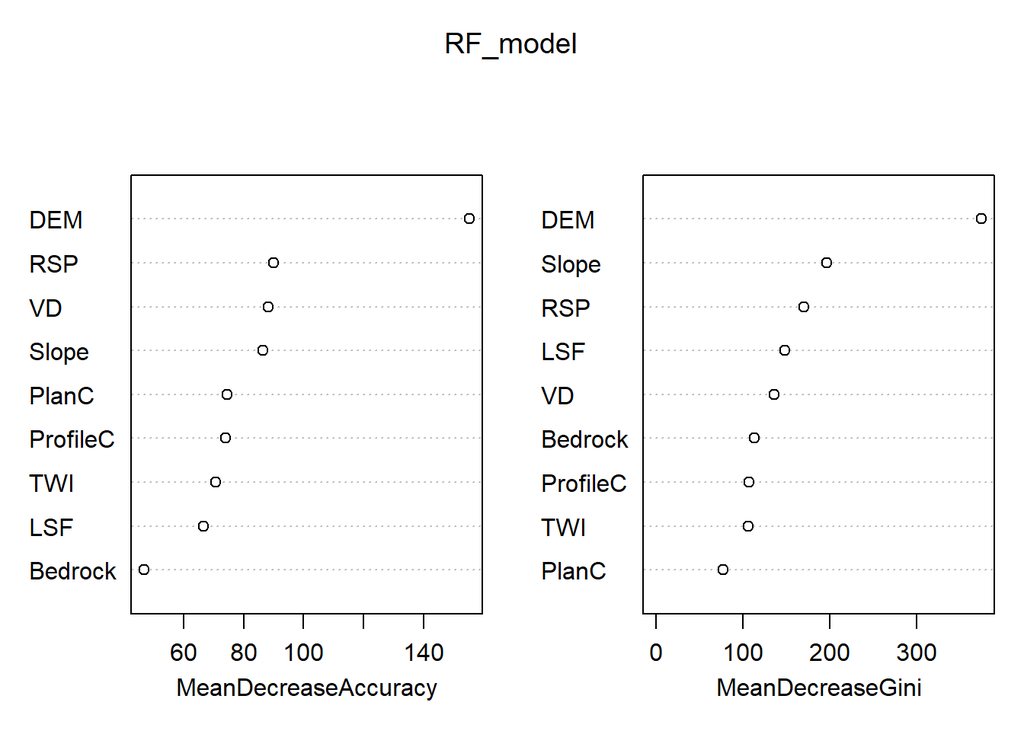

```r
sampData3 <- extract(covStack, shpPoint3, sp = TRUE,method = "simple")
sampData3<-sampData3@data

sampData<-rbind(sampData1,sampData2,sampData3)
sampData<-na.omit(sampData)

sampData$soilID<-substring(as.vector(sampData$soilID),2,nchar(as.vector(sampData$soilID)))

sampData$Bedrock<-as.factor(sampData$Bedrock)
sampData$soilID<-as.factor(sampData$soilID)

RF_model<-randomForest(soilID ~.,data = sampData,
                       importance = TRUE, proximity = FALSE,ntree=1000,type="classification")

varImpPlot(RF_model)
```

```r
print(RF_model)
```

```
##
## Call:
##  randomForest(formula = soilID ~ ., data = sampData, importance = TRUE,      proximity = FALSE, ntree = 1000, type = "classification")
##                Type of random forest: classification
##                      Number of trees: 1000
## No. of variables tried at each split: 3
##
##         OOB estimate of  error rate: 12.95%
## Confusion matrix:
##     1  20 21  23  3 30 31 501 502 503   7 class.error
## 1   9   0  0   0  2  0  0   0   0   0   0  0.18181818
## 20  0 167 17   0  0  0  0   2   0  17  24  0.26431718
## 21  0  15 88   0  0  0  0   1   0   2   1  0.17757009
## 23  0   0  0 129  0  1  3   0   0   7   0  0.07857143
## 3   2   0  0   0 65  0  0  22   0   0   0  0.26966292
## 30  0   0  0   6  0 35  0   0   0   0   1  0.16666667
## 31  0   0  0   4  0  1 63   0   0   0   0  0.07352941
## 501 0   1  0   0 19  0  0 282   0   0   3  0.07540984
## 502 0   3  0   0  0  0  0   3  27   1   2  0.25000000
## 503 0  12  3   7  0  0  0   0   0 371   5  0.06783920
## 7   0  14  0   0  0  2  0   6   0   8 223  0.11857708
```

```r
map_RF <- predict(covStack, RF_model, paste(result_tif_folder,"SNA_NS5_Slope0PlanC0TWI.tif",sep=""),
                  format = "GTiff", datatype = "FLT4S", overwrite = TRUE)


rm("mn1","shpPoint1","sampData1","mn2","shpPoint2","sampData2","mn3","shpPoint3","sampData3","sampData","RF_model","map_RF")
```

# 多因子计算精度

```r
#设置最终结果tif的保存路径
result_tif_folder="E:/otherWork/02_1/soil2019-rewrite/result_mapTif/"

multi_result_map_name<-c("SNA_NS3_DEM0Slope0PlanC","SNA_NS5_DEM0Slope0PlanC",
                   "SNA_NS3_DEM0Slope0TWI","SNA_NS5_DEM0Slope0TWI",
                   "SNA_NS3_DEM0PlanC0TWI","SNA_NS5_DEM0PlanC0TWI",
                   "SNA_NS3_Slope0PlanC0TWI","SNA_NS5_Slope0PlanC0TWI")

multi_resultCovStack<-raster(paste(result_tif_folder,multi_result_map_name[1],".tif",sep = ""))
for (i in 2:length(multi_result_map_name)) {
  multi_resultCovStack <- stack(multi_resultCovStack, paste(result_tif_folder,multi_result_map_name[i],".tif",sep = ""))
}

validationPoint<-readOGR(paste(result_tif_folder,"validationPoint.shp",sep = "")) ###
```

```r
multi_vp_data <- extract(multi_resultCovStack, validationPoint, sp = TRUE,method = "simple")
multi_vp_data<-na.omit(multi_vp_data@data)

hsm<-raster(paste(result_tif_folder,"historical_soil_map.tif",sep = ""))
soil_type<- unique(hsm)
multi_vp_data<-multi_vp_data[multi_vp_data$trueType %in% soil_type,]

print(nrow(multi_vp_data))
```

```
## [1] 92
```

```r
multi_precision_df<-data.frame("method"=rep(NA,length(multi_result_map_name)),
                         "factor"=rep(NA,length(multi_result_map_name)),
                         "NS"=rep(NA,length(multi_result_map_name)),
                         "percent"=rep(NA,length(multi_result_map_name)),
                         "precisionValue"=rep(NA,length(multi_result_map_name)))

for (i in 1:length(multi_result_map_name)){
  fna<-multi_result_map_name[i]
  ns_split<-unlist(strsplit(fna,"_"))

  multi_precision_df[i,]$method<-ns_split[1]
  multi_precision_df[i,]$factor<-ns_split[3]
  multi_precision_df[i,]$NS<-ns_split[2]
  multi_precision_df[i,]$percent<-"pen75"
  multi_precision_df[i,]$precisionValue<-round( sum(multi_vp_data$trueType==multi_vp_data[fna])/nrow(multi_vp_data),4)

}

mfa<-unique(multi_precision_df$factor)
mfa_precision<-c()
for(mfai in mfa){
  i_split<-unlist(strsplit(mfai,"0"))
  temp_value<-round(mean(c(subset(precision_df,NS=="RAN" & percent=="pen75" & factor==i_split[1])$precisionValue,
                     subset(precision_df,NS=="RAN" & percent=="pen75" & factor==i_split[2])$precisionValue,
                     subset(precision_df,NS=="RAN" & percent=="pen75" & factor==i_split[3])$precisionValue)),4)
  mfa_precision<-c(mfa_precision,temp_value)
}


multi_precision_df_2<-data.frame("method"=rep("RAN",length(mfa)),
                         "factor"=mfa,
                         "NS"=rep("RAN",length(mfa)),
                         "percent"=rep("pen75",length(mfa)),
                         "precisionValue"=mfa_precision)

multi_precision_df<-rbind(multi_precision_df,multi_precision_df_2)

precision_oldSoilMap<-round( sum(multi_vp_data$trueType==multi_vp_data$oldSoilMap)/nrow(multi_vp_data),4)
print(precision_oldSoilMap)
```

```
## [1] 0.6196
```

```r
print(multi_precision_df)
```

```
##    method          factor  NS percent precisionValue
## 1     SNA DEM0Slope0PlanC NS3   pen75         0.5652
## 2     SNA DEM0Slope0PlanC NS5   pen75         0.5543
## 3     SNA   DEM0Slope0TWI NS3   pen75         0.5326
## 4     SNA   DEM0Slope0TWI NS5   pen75         0.5543
## 5     SNA   DEM0PlanC0TWI NS3   pen75         0.5652
## 6     SNA   DEM0PlanC0TWI NS5   pen75         0.5978
## 7     SNA Slope0PlanC0TWI NS3   pen75         0.6196
## 8     SNA Slope0PlanC0TWI NS5   pen75         0.6196
## 9     RAN DEM0Slope0PlanC RAN   pen75         0.6377
## 10    RAN   DEM0Slope0TWI RAN   pen75         0.6304
## 11    RAN   DEM0PlanC0TWI RAN   pen75         0.6413
## 12    RAN Slope0PlanC0TWI RAN   pen75         0.6341
```